# Interactive effects of task repetition, task motivation and task engagement on CAL in L2 writing

Webpage created and maintained by Reza Norouzian* © 2022-present

Reza Norouzian

1/3/2023

# 1 Statitical modeling

Given the use of multiple CAL measures in our study, our candidate statistical model, which was fit using the `nlme` package in `R`, included several characteristics.

First, the model assumed that CAL measures used in our study were a random sample of a larger set of possible CAL measures available in the literature. As a result, CAL measures were considered to be random-effects for each participant across all the participants.

Second, these CAL measure random-effects were found to be non-overlapping (uncorrelated) with one another for each participant across all the participants.

Third, the CAL measure random-effects seemed to have different amounts of variation from one measure to another (i.e., were heterogeneous) for each participant across all the participants ($\tau$ in the model characteristics tables).

Fourth, although the random-effects seemed to be uncorrelated, the residuals of the model (i.e., distances between CAL scores and their model-predicted counterparts) seemed to be slightly correlated common to each participant across all the participants ($\rho$ in the model characteristics tables).

Finally, in addition to their correlation, the variation in the residuals of the model seemed to differ across both different CAL measures as well as different times of CAL measurement ($\sigma$ in the model characteristics tables).

This level of flexibility allowed the model to accommodate the various types of CAL measures, differences in their scales of measurement, as well as violations of their underlying distributional assumptions (e.g., normality).

In the tables to follow, these model characteristics will also be quantified and displayed separately for each research question.

# 2 RQ1: To what extent can task repetition impact measures of L2 writing syntactic complexity, accuracy, and lexical complexity?

The impact of task repetition on CAL measures

| time | cal | Mean | SE | Lower | Upper | t | p-value | Sig. |
| --- | --- | --- | --- | --- | --- | --- | --- | --- |
| 1 | ac_EFC/C | 0.41 | 0.08 | 0.26 | 0.56 | 5.28 | 0.00 | *** |
| 2 | ac_EFC/C | 0.35 | 0.06 | 0.23 | 0.47 | 5.82 | 0.00 | *** |
| 3 | ac_EFC/C | 0.77 | 0.05 | 0.66 | 0.87 | 14.34 | 0.00 | *** |
| 4 | ac_EFC/C | 0.56 | 0.05 | 0.46 | 0.65 | 11.29 | 0.00 | *** |
| 1 | com_CN/C | 1.09 | 0.03 | 1.03 | 1.15 | 36.59 | 0.00 | *** |
| 2 | com_CN/C | 1.06 | 0.02 | 1.02 | 1.11 | 46.18 | 0.00 | *** |
| 3 | com_CN/C | 1.13 | 0.02 | 1.09 | 1.17 | 54.95 | 0.00 | *** |
| 4 | com_CN/C | 1.06 | 0.02 | 1.03 | 1.10 | 56.48 | 0.00 | *** |
| 1 | com_CN/T | 1.84 | 0.02 | 1.81 | 1.87 | 121.24 | 0.00 | *** |
| 2 | com_CN/T | 1.81 | 0.01 | 1.78 | 1.83 | 153.83 | 0.00 | *** |
| 3 | com_CN/T | 1.90 | 0.01 | 1.88 | 1.92 | 181.64 | 0.00 | *** |
| 4 | com_CN/T | 1.90 | 0.01 | 1.88 | 1.92 | 197.55 | 0.00 | *** |
| 1 | com_DC/T | 0.87 | 0.08 | 0.70 | 1.04 | 10.35 | 0.00 | *** |
| 2 | com_DC/T | 0.72 | 0.06 | 0.59 | 0.85 | 11.05 | 0.00 | *** |
| 3 | com_DC/T | 1.04 | 0.06 | 0.93 | 1.16 | 18.05 | 0.00 | *** |
| 4 | com_DC/T | 0.96 | 0.05 | 0.86 | 1.07 | 18.14 | 0.00 | *** |
| 1 | com_MLTU | 16.24 | 0.18 | 15.89 | 16.60 | 91.13 | 0.00 | *** |
| 2 | com_MLTU | 15.39 | 0.14 | 15.12 | 15.67 | 111.76 | 0.00 | *** |
| 3 | com_MLTU | 16.78 | 0.12 | 16.54 | 17.03 | 137.06 | 0.00 | *** |
| 4 | com_MLTU | 16.79 | 0.11 | 16.57 | 17.02 | 149.09 | 0.00 | *** |
| 1 | lex_Vocd | 68.49 | 1.01 | 66.49 | 70.49 | 67.83 | 0.00 | *** |
| 2 | lex_Vocd | 69.85 | 0.78 | 68.30 | 71.40 | 89.52 | 0.00 | *** |
| 3 | lex_Vocd | 71.28 | 0.69 | 69.91 | 72.66 | 102.77 | 0.00 | *** |
| 4 | lex_Vocd | 71.69 | 0.64 | 70.43 | 72.96 | 112.37 | 0.00 | *** |
| 1 | lex_WRDFRQmc | 1.74 | 0.01 | 1.71 | 1.76 | 124.23 | 0.00 | *** |
| 2 | lex_WRDFRQmc | 1.71 | 0.01 | 1.69 | 1.73 | 158.66 | 0.00 | *** |
| 3 | lex_WRDFRQmc | 1.74 | 0.01 | 1.72 | 1.76 | 181.45 | 0.00 | *** |
| 4 | lex_WRDFRQmc | 1.77 | 0.01 | 1.75 | 1.78 | 199.97 | 0.00 | *** |

Quantification of the model characteristics

| Terms | τ (SD) | ρ | σ (SD) |
| --- | --- | --- | --- |
| **Random-Effects’ Variation Across CALs** |  |  |  |
| ac_EFC/C | 0.046968 |  |  |
| com_CN/C | 0.000821 |  |  |
| com_CN/T | 0.000006 |  |  |
| com_DC/T | 0.000022 |  |  |
| com_MLTU | 0.000030 |  |  |
| lex_Vocd | 0.007035 |  |  |
| lex_WRDFRQmc | 0.000038 |  |  |
| **Residuals’ Common Corr. Across Participants** |  |  |  |
| Corr. Estimate |  | 0.006 |  |
| **Residuals’ Variation Across Times and CALs** |  |  |  |
| Time 1 |  |  | 1.783 |
| Time 2 |  |  | 1.567 |
| Time 3 |  |  | 1.477 |
| Time 4 |  |  | 1.417 |
| com_MLTU |  |  | 1.783 |
| com_DC/T |  |  | 1.223 |
| com_CN/T |  |  | 0.521 |
| com_CN/C |  |  | 0.729 |
| ac_EFC/C |  |  | 1.175 |
| lex_Vocd |  |  | 4.243 |
| lex_WRDFRQmc |  |  | 0.499 |

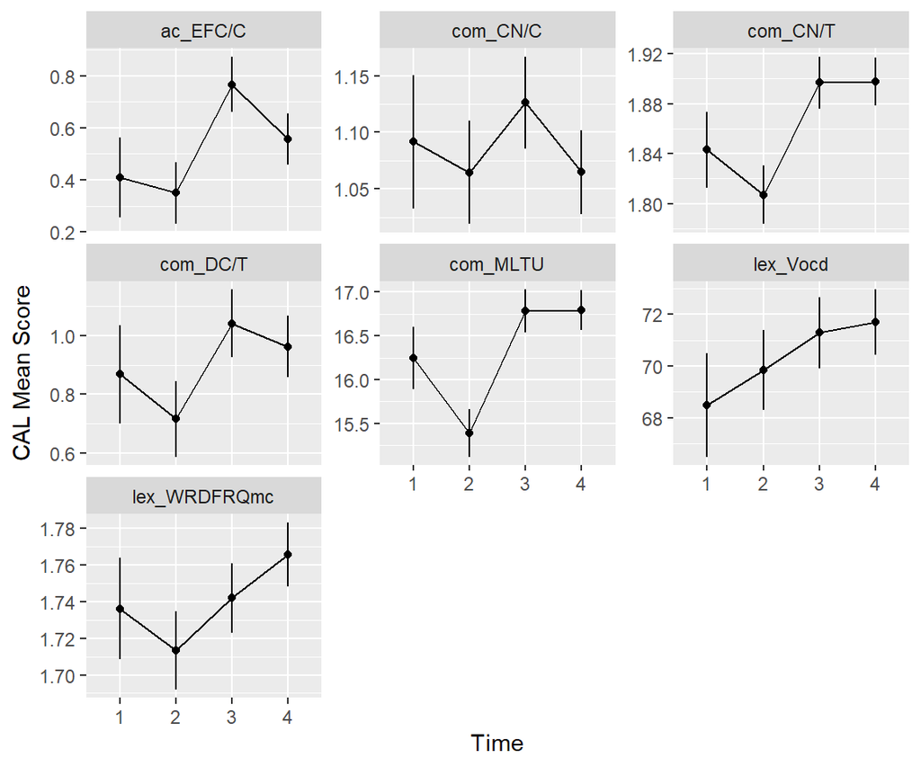

Figure 1. The impact of task repetition on CAL measures

# 3 RQ2a: To what extent is that impact moderated by the level of task difficulty?

The impact of task repetition on CAL measures moderated by task difficulty

task_dif

time

cal

Mean

SE

Lower

Upper

t

p-value

Sig.

complex

1

ac_EFC/C

0.559

0.100

0.361

0.758

5.592

0.000

***

simple

1

ac_EFC/C

0.260

0.100

0.062

0.459

2.601

0.011

complex

2

ac_EFC/C

0.365

0.078

0.211

0.519

4.703

0.000

***

simple

2

ac_EFC/C

0.334

0.078

0.180

0.488

4.297

0.000

***

complex

3

ac_EFC/C

1.222

0.066

1.091

1.352

18.581

0.000

***

simple

3

ac_EFC/C

0.311

0.066

0.180

0.441

4.726

0.000

***

complex

4

ac_EFC/C

0.682

0.064

0.556

0.809

10.695

0.000

***

simple

4

ac_EFC/C

0.429

0.064

0.302

0.556

6.726

0.000

***

complex

1

com_CN/C

1.085

0.043

1.001

1.170

25.450

0.000

***

simple

1

com_CN/C

1.098

0.043

1.013

1.182

25.738

0.000

***

complex

2

com_CN/C

1.104

0.033

1.039

1.169

33.642

0.000

***

simple

2

com_CN/C

1.025

0.033

0.960

1.090

31.228

0.000

***

complex

3

com_CN/C

1.107

0.028

1.053

1.162

40.222

0.000

***

simple

3

com_CN/C

1.145

0.028

1.090

1.199

41.588

0.000

***

complex

4

com_CN/C

1.109

0.027

1.056

1.161

41.612

0.000

***

simple

4

com_CN/C

1.021

0.027

0.968

1.073

38.309

0.000

***

complex

1

com_CN/T

1.811

0.021

1.769

1.854

84.361

0.000

***

simple

1

com_CN/T

1.875

0.021

1.832

1.917

87.328

0.000

***

complex

2

com_CN/T

1.825

0.017

1.792

1.858

110.450

0.000

***

simple

2

com_CN/T

1.789

0.017

1.756

1.822

108.283

0.000

***

complex

3

com_CN/T

1.916

0.014

1.889

1.944

138.274

0.000

***

simple

3

com_CN/T

1.877

0.014

1.850

1.905

135.459

0.000

***

complex

4

com_CN/T

1.894

0.013

1.867

1.921

141.221

0.000

***

simple

4

com_CN/T

1.901

0.013

1.874

1.928

141.743

0.000

***

complex

1

com_DC/T

0.876

0.121

0.636

1.117

7.228

0.000

***

simple

1

com_DC/T

0.861

0.121

0.620

1.101

7.099

0.000

***

complex

2

com_DC/T

0.733

0.093

0.548

0.919

7.860

0.000

***

simple

2

com_DC/T

0.701

0.093

0.516

0.886

7.510

0.000

***

complex

3

com_DC/T

1.027

0.078

0.872

1.182

13.123

0.000

***

simple

3

com_DC/T

1.054

0.078

0.899

1.210

13.471

0.000

***

complex

4

com_DC/T

0.878

0.076

0.728

1.028

11.589

0.000

***

simple

4

com_DC/T

1.047

0.076

0.897

1.197

13.820

0.000

***

complex

1

com_MLTU

16.252

0.254

15.749

16.756

64.045

0.000

***

simple

1

com_MLTU

16.237

0.254

15.733

16.741

63.984

0.000

***

complex

2

com_MLTU

15.587

0.195

15.199

15.974

79.816

0.000

***

simple

2

com_MLTU

15.200

0.195

14.812

15.587

77.836

0.000

***

complex

3

com_MLTU

17.107

0.164

16.782

17.432

104.437

0.000

***

simple

3

com_MLTU

16.460

0.164

16.135

16.785

100.489

0.000

***

complex

4

com_MLTU

17.028

0.159

16.713

17.342

107.416

0.000

***

simple

4

com_MLTU

16.556

0.159

16.241

16.870

104.438

0.000

***

complex

1

lex_Vocd

68.860

1.446

65.991

71.729

47.625

0.000

***

simple

1

lex_Vocd

68.122

1.446

65.253

70.991

47.114

0.000

***

complex

2

lex_Vocd

69.316

1.113

67.108

71.524

62.298

0.000

***

simple

2

lex_Vocd

70.390

1.113

68.182

72.597

63.263

0.000

***

complex

3

lex_Vocd

73.270

0.933

71.419

75.122

78.509

0.000

***

simple

3

lex_Vocd

69.299

0.933

67.447

71.150

74.253

0.000

***

complex

4

lex_Vocd

71.050

0.903

69.258

72.842

78.664

0.000

***

simple

4

lex_Vocd

72.334

0.903

70.542

74.127

80.086

0.000

***

complex

1

lex_WRDFRQmc

1.740

0.020

1.700

1.780

86.134

0.000

***

simple

1

lex_WRDFRQmc

1.732

0.020

1.692

1.772

85.719

0.000

***

complex

2

lex_WRDFRQmc

1.710

0.016

1.679

1.741

109.976

0.000

***

simple

2

lex_WRDFRQmc

1.717

0.016

1.686

1.748

110.413

0.000

***

complex

3

lex_WRDFRQmc

1.755

0.013

1.729

1.781

134.579

0.000

***

simple

3

lex_WRDFRQmc

1.729

0.013

1.703

1.755

132.555

0.000

***

complex

4

lex_WRDFRQmc

1.773

0.013

1.748

1.798

140.469

0.000

***

simple

4

lex_WRDFRQmc

1.759

0.013

1.734

1.784

139.344

0.000

***

Quantification of the model characteristics

| Terms | τ (SD) | ρ | σ (SD) |
| --- | --- | --- | --- |
| **Random-Effects’ Variation Across CALs** |  |  |  |
| ac_EFC/C | 0.116017 |  |  |
| com_CN/C | 0.000027 |  |  |
| com_CN/T | 0.000002 |  |  |
| com_DC/T | 0.000004 |  |  |
| com_MLTU | 0.000009 |  |  |
| lex_Vocd | 0.000366 |  |  |
| lex_WRDFRQmc | 0.000035 |  |  |
| **Residuals’ Common Corr. Across Participants** |  |  |  |
| Corr. Estimate |  | 0.007 |  |
| **Residuals’ Variation Across Times and CALs** |  |  |  |
| Time 1 |  |  | 1.794 |
| Time 2 |  |  | 1.574 |
| Time 3 |  |  | 1.442 |
| Time 4 |  |  | 1.418 |
| com_MLTU |  |  | 1.794 |
| com_DC/T |  |  | 1.240 |
| com_CN/T |  |  | 0.522 |
| com_CN/C |  |  | 0.736 |
| ac_EFC/C |  |  | 1.119 |
| lex_Vocd |  |  | 4.283 |
| lex_WRDFRQmc |  |  | 0.506 |

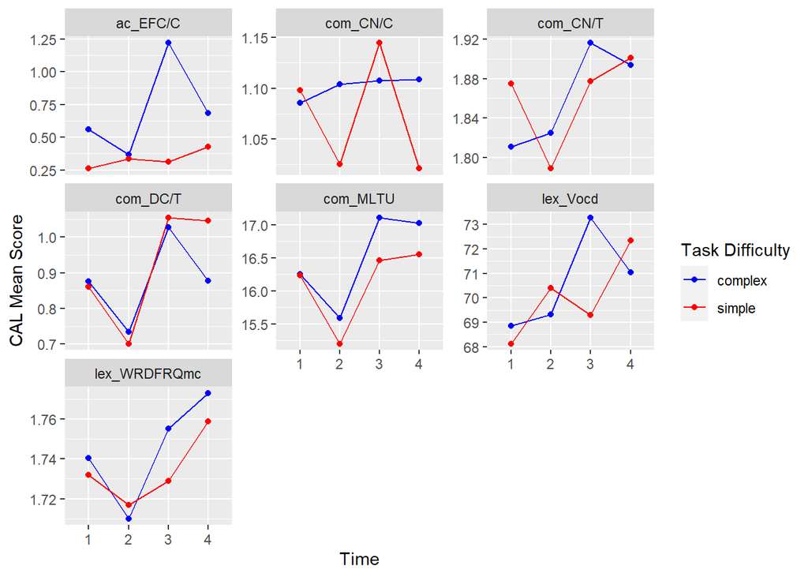

Figure 2. The impact of task repetition on CAL measures moderated by task difficulty

# 4 RQ2b

## 4.1 To what extent is that impact moderated by the level of task external motivation for simple and complex tasks?

The impact of task repetition on CAL measures moderated by external motivation for simple and complex tasks

extr

time

cal

task_dif

Mean

SE

Lower

Upper

t

p-value

Sig.

2.100

1

ac_EFC/C

complex

0.513

0.111

0.293

0.733

4.631

0.000

***

3.200

1

ac_EFC/C

complex

0.307

0.285

-0.259

0.872

1.076

0.285

4.300

1

ac_EFC/C

complex

0.100

0.495

-0.883

1.083

0.202

0.840

2.100

2

ac_EFC/C

complex

0.384

0.078

0.228

0.539

4.900

0.000

***

3.200

2

ac_EFC/C

complex

0.584

0.196

0.194

0.973

2.974

0.004

4.300

2

ac_EFC/C

complex

0.784

0.355

0.080

1.488

2.211

0.029

2.100

3

ac_EFC/C

complex

1.395

0.089

1.219

1.571

15.713

0.000

***

3.200

3

ac_EFC/C

complex

0.919

0.124

0.674

1.165

7.428

0.000

***

4.300

3

ac_EFC/C

complex

0.443

0.278

-0.108

0.995

1.595

0.114

2.100

4

ac_EFC/C

complex

0.691

0.081

0.530

0.852

8.522

0.000

***

3.200

4

ac_EFC/C

complex

0.666

0.113

0.441

0.891

5.874

0.000

***

4.300

4

ac_EFC/C

complex

0.642

0.248

0.150

1.134

2.587

0.011

2.100

1

com_CN/C

complex

1.110

0.048

1.015

1.204

23.345

0.000

***

3.200

1

com_CN/C

complex

1.217

0.122

0.974

1.461

9.939

0.000

***

4.300

1

com_CN/C

complex

1.325

0.213

0.903

1.748

6.224

0.000

***

2.100

2

com_CN/C

complex

1.102

0.033

1.037

1.168

33.164

0.000

***

3.200

2

com_CN/C

complex

1.085

0.084

0.919

1.251

12.962

0.000

***

4.300

2

com_CN/C

complex

1.067

0.151

0.767

1.367

7.054

0.000

***

2.100

3

com_CN/C

complex

1.108

0.037

1.034

1.182

29.594

0.000

***

3.200

3

com_CN/C

complex

1.106

0.052

1.002

1.210

21.167

0.000

***

4.300

3

com_CN/C

complex

1.104

0.118

0.871

1.338

9.398

0.000

***

2.100

4

com_CN/C

complex

1.101

0.034

1.033

1.169

32.312

0.000

***

3.200

4

com_CN/C

complex

1.123

0.048

1.028

1.217

23.508

0.000

***

4.300

4

com_CN/C

complex

1.144

0.105

0.937

1.352

10.940

0.000

***

2.100

1

com_CN/T

complex

1.804

0.024

1.756

1.851

74.826

0.000

***

3.200

1

com_CN/T

complex

1.769

0.062

1.646

1.892

28.482

0.000

***

4.300

1

com_CN/T

complex

1.735

0.108

1.521

1.949

16.066

0.000

***

2.100

2

com_CN/T

complex

1.829

0.017

1.795

1.862

108.466

0.000

***

3.200

2

com_CN/T

complex

1.870

0.042

1.785

1.954

44.060

0.000

***

4.300

2

com_CN/T

complex

1.911

0.077

1.759

2.063

24.911

0.000

***

2.100

3

com_CN/T

complex

1.919

0.019

1.881

1.957

101.090

0.000

***

3.200

3

com_CN/T

complex

1.911

0.026

1.858

1.964

72.116

0.000

***

4.300

3

com_CN/T

complex

1.903

0.060

1.785

2.021

31.935

0.000

***

2.100

4

com_CN/T

complex

1.890

0.017

1.856

1.924

109.363

0.000

***

3.200

4

com_CN/T

complex

1.902

0.024

1.854

1.950

78.535

0.000

***

4.300

4

com_CN/T

complex

1.914

0.053

1.808

2.019

36.086

0.000

***

2.100

1

com_DC/T

complex

0.853

0.135

0.586

1.120

6.337

0.000

***

3.200

1

com_DC/T

complex

0.746

0.347

0.058

1.434

2.151

0.034

4.300

1

com_DC/T

complex

0.639

0.603

-0.557

1.835

1.060

0.292

2.100

2

com_DC/T

complex

0.721

0.094

0.534

0.908

7.660

0.000

***

3.200

2

com_DC/T

complex

0.582

0.237

0.112

1.052

2.458

0.016

4.300

2

com_DC/T

complex

0.444

0.428

-0.406

1.293

1.036

0.303

2.100

3

com_DC/T

complex

1.024

0.106

0.813

1.234

9.658

0.000

***

3.200

3

com_DC/T

complex

1.034

0.148

0.740

1.327

6.987

0.000

***

4.300

3

com_DC/T

complex

1.044

0.333

0.384

1.704

3.137

0.002

2.100

4

com_DC/T

complex

1.001

0.096

0.809

1.192

10.375

0.000

***

3.200

4

com_DC/T

complex

0.651

0.135

0.383

0.919

4.818

0.000

***

4.300

4

com_DC/T

complex

0.302

0.296

-0.286

0.889

1.019

0.310

2.100

1

com_MLTU

complex

16.272

0.283

15.712

16.833

57.581

0.000

***

3.200

1

com_MLTU

complex

16.361

0.728

14.916

17.807

22.465

0.000

***

4.300

1

com_MLTU

complex

16.450

1.266

13.938

18.963

12.992

0.000

***

2.100

2

com_MLTU

complex

15.587

0.198

15.195

15.979

78.858

0.000

***

3.200

2

com_MLTU

complex

15.591

0.498

14.604

16.578

31.337

0.000

***

4.300

2

com_MLTU

complex

15.595

0.899

13.810

17.379

17.341

0.000

***

2.100

3

com_MLTU

complex

17.029

0.223

16.588

17.471

76.507

0.000

***

3.200

3

com_MLTU

complex

17.242

0.311

16.625

17.858

55.492

0.000

***

4.300

3

com_MLTU

complex

17.454

0.699

16.068

18.840

24.982

0.000

***

2.100

4

com_MLTU

complex

17.391

0.203

16.989

17.794

85.839

0.000

***

3.200

4

com_MLTU

complex

16.357

0.284

15.793

16.920

57.611

0.000

***

4.300

4

com_MLTU

complex

15.322

0.622

14.088

16.556

24.643

0.000

***

2.100

1

lex_Vocd

complex

68.866

1.631

65.631

72.102

42.232

0.000

***

3.200

1

lex_Vocd

complex

68.894

4.203

60.556

77.233

16.393

0.000

***

4.300

1

lex_Vocd

complex

68.922

7.306

54.425

83.419

9.434

0.000

***

2.100

2

lex_Vocd

complex

69.557

1.141

67.294

71.820

60.986

0.000

***

3.200

2

lex_Vocd

complex

72.204

2.871

66.507

77.900

25.150

0.000

***

4.300

2

lex_Vocd

complex

74.851

5.189

64.554

85.148

14.424

0.000

***

2.100

3

lex_Vocd

complex

73.692

1.284

71.144

76.241

57.375

0.000

***

3.200

3

lex_Vocd

complex

72.532

1.793

68.975

76.090

40.457

0.000

***

4.300

3

lex_Vocd

complex

71.373

4.031

63.374

79.372

17.704

0.000

***

2.100

4

lex_Vocd

complex

71.017

1.169

68.697

73.337

60.746

0.000

***

3.200

4

lex_Vocd

complex

71.111

1.638

67.860

74.362

43.405

0.000

***

4.300

4

lex_Vocd

complex

71.205

3.588

64.086

78.324

19.846

0.000

***

2.100

1

lex_WRDFRQmc

complex

1.747

0.023

1.702

1.792

76.895

0.000

***

3.200

1

lex_WRDFRQmc

complex

1.775

0.059

1.659

1.891

30.321

0.000

***

4.300

1

lex_WRDFRQmc

complex

1.803

0.102

1.602

2.005

17.720

0.000

***

2.100

2

lex_WRDFRQmc

complex

1.713

0.016

1.681

1.744

107.788

0.000

***

3.200

2

lex_WRDFRQmc

complex

1.741

0.040

1.662

1.820

43.531

0.000

***

4.300

2

lex_WRDFRQmc

complex

1.769

0.072

1.626

1.913

24.475

0.000

***

2.100

3

lex_WRDFRQmc

complex

1.771

0.018

1.735

1.806

98.956

0.000

***

3.200

3

lex_WRDFRQmc

complex

1.728

0.025

1.679

1.778

69.202

0.000

***

4.300

3

lex_WRDFRQmc

complex

1.686

0.056

1.575

1.798

30.023

0.000

***

2.100

4

lex_WRDFRQmc

complex

1.780

0.016

1.748

1.812

109.286

0.000

***

3.200

4

lex_WRDFRQmc

complex

1.760

0.023

1.715

1.806

77.135

0.000

***

4.300

4

lex_WRDFRQmc

complex

1.741

0.050

1.642

1.840

34.833

0.000

***

2.100

1

ac_EFC/C

simple

0.470

0.283

-0.091

1.032

1.661

0.100

.

3.200

1

ac_EFC/C

simple

0.325

0.129

0.069

0.581

2.523

0.013

4.300

1

ac_EFC/C

simple

0.180

0.142

-0.101

0.461

1.272

0.206

2.100

2

ac_EFC/C

simple

0.214

0.280

-0.340

0.769

0.767

0.445

3.200

2

ac_EFC/C

simple

0.287

0.131

0.027

0.546

2.194

0.031

4.300

2

ac_EFC/C

simple

0.359

0.096

0.169

0.549

3.748

0.000

***

2.100

3

ac_EFC/C

simple

0.398

0.380

-0.355

1.152

1.049

0.297

3.200

3

ac_EFC/C

simple

0.356

0.206

-0.052

0.765

1.732

0.086

.

4.300

3

ac_EFC/C

simple

0.315

0.067

0.181

0.448

4.669

0.000

***

2.100

4

ac_EFC/C

simple

1.219

0.416

0.393

2.045

2.927

0.004

3.200

4

ac_EFC/C

simple

0.851

0.229

0.397

1.304

3.722

0.000

***

4.300

4

ac_EFC/C

simple

0.483

0.069

0.346

0.619

7.016

0.000

***

2.100

1

com_CN/C

simple

1.087

0.122

0.845

1.328

8.931

0.000

***

3.200

1

com_CN/C

simple

1.094

0.055

0.985

1.204

19.777

0.000

***

4.300

1

com_CN/C

simple

1.102

0.061

0.981

1.223

18.117

0.000

***

2.100

2

com_CN/C

simple

1.367

0.119

1.131

1.604

11.468

0.000

***

3.200

2

com_CN/C

simple

1.160

0.056

1.049

1.270

20.830

0.000

***

4.300

2

com_CN/C

simple

0.952

0.041

0.871

1.033

23.351

0.000

***

2.100

3

com_CN/C

simple

1.025

0.161

0.707

1.344

6.387

0.000

***

3.200

3

com_CN/C

simple

1.082

0.087

0.910

1.255

12.446

0.000

***

4.300

3

com_CN/C

simple

1.140

0.028

1.083

1.196

40.185

0.000

***

2.100

4

com_CN/C

simple

0.949

0.176

0.601

1.298

5.406

0.000

***

3.200

4

com_CN/C

simple

0.983

0.096

0.791

1.174

10.195

0.000

***

4.300

4

com_CN/C

simple

1.016

0.029

0.958

1.073

35.171

0.000

***

2.100

1

com_CN/T

simple

1.795

0.062

1.672

1.917

29.087

0.000

***

3.200

1

com_CN/T

simple

1.850

0.028

1.794

1.906

65.934

0.000

***

4.300

1

com_CN/T

simple

1.905

0.031

1.844

1.967

61.778

0.000

***

2.100

2

com_CN/T

simple

1.809

0.060

1.689

1.929

29.920

0.000

***

3.200

2

com_CN/T

simple

1.797

0.028

1.741

1.853

63.651

0.000

***

4.300

2

com_CN/T

simple

1.785

0.021

1.744

1.826

86.336

0.000

***

2.100

3

com_CN/T

simple

1.847

0.081

1.686

2.009

22.693

0.000

***

3.200

3

com_CN/T

simple

1.862

0.044

1.774

1.949

42.207

0.000

***

4.300

3

com_CN/T

simple

1.876

0.014

1.847

1.904

130.438

0.000

***

2.100

4

com_CN/T

simple

1.925

0.089

1.748

2.102

21.618

0.000

***

3.200

4

com_CN/T

simple

1.914

0.049

1.817

2.011

39.161

0.000

***

4.300

4

com_CN/T

simple

1.903

0.015

1.874

1.932

129.912

0.000

***

2.100

1

com_DC/T

simple

1.465

0.344

0.781

2.148

4.253

0.000

***

3.200

1

com_DC/T

simple

1.048

0.157

0.737

1.359

6.690

0.000

***

4.300

1

com_DC/T

simple

0.631

0.172

0.289

0.973

3.665

0.000

***

2.100

2

com_DC/T

simple

1.322

0.337

0.652

1.991

3.917

0.000

***

3.200

2

com_DC/T

simple

0.945

0.158

0.632

1.258

5.997

0.000

***

4.300

2

com_DC/T

simple

0.568

0.115

0.339

0.797

4.925

0.000

***

2.100

3

com_DC/T

simple

0.949

0.454

0.047

1.850

2.088

0.039

3.200

3

com_DC/T

simple

0.999

0.246

0.511

1.488

4.059

0.000

***

4.300

3

com_DC/T

simple

1.050

0.080

0.891

1.209

13.077

0.000

***

2.100

4

com_DC/T

simple

1.907

0.497

0.921

2.893

3.836

0.000

***

3.200

4

com_DC/T

simple

1.506

0.273

0.965

2.047

5.521

0.000

***

4.300

4

com_DC/T

simple

1.105

0.082

0.943

1.267

13.518

0.000

***

2.100

1

com_MLTU

simple

15.843

0.723

14.408

17.279

21.901

0.000

***

3.200

1

com_MLTU

simple

16.115

0.329

15.462

16.768

48.984

0.000

***

4.300

1

com_MLTU

simple

16.387

0.362

15.669

17.104

45.314

0.000

***

2.100

2

com_MLTU

simple

14.907

0.709

13.501

16.314

21.030

0.000

***

3.200

2

com_MLTU

simple

15.085

0.331

14.428

15.741

45.576

0.000

***

4.300

2

com_MLTU

simple

15.262

0.242

14.781

15.743

62.968

0.000

***

2.100

3

com_MLTU

simple

16.113

0.954

14.220

18.007

16.884

0.000

***

3.200

3

com_MLTU

simple

16.279

0.517

15.253

17.305

31.480

0.000

***

4.300

3

com_MLTU

simple

16.445

0.169

16.110

16.780

97.526

0.000

***

2.100

4

com_MLTU

simple

18.590

1.044

16.518

20.662

17.803

0.000

***

3.200

4

com_MLTU

simple

17.642

0.573

16.505

18.779

30.787

0.000

***

4.300

4

com_MLTU

simple

16.694

0.172

16.353

17.034

97.216

0.000

***

2.100

1

lex_Vocd

simple

69.098

4.174

60.815

77.381

16.553

0.000

***

3.200

1

lex_Vocd

simple

68.424

1.898

64.657

72.191

36.044

0.000

***

4.300

1

lex_Vocd

simple

67.750

2.087

63.610

71.891

32.468

0.000

***

2.100

2

lex_Vocd

simple

72.850

4.090

64.734

80.966

17.811

0.000

***

3.200

2

lex_Vocd

simple

71.358

1.910

67.568

75.147

37.363

0.000

***

4.300

2

lex_Vocd

simple

69.865

1.399

67.090

72.640

49.954

0.000

***

2.100

3

lex_Vocd

simple

74.052

5.507

63.125

84.979

13.447

0.000

***

3.200

3

lex_Vocd

simple

71.779

2.984

65.858

77.700

24.055

0.000

***

4.300

3

lex_Vocd

simple

69.505

0.973

67.575

71.436

71.435

0.000

***

2.100

4

lex_Vocd

simple

75.728

6.025

63.772

87.683

12.569

0.000

***

3.200

4

lex_Vocd

simple

74.146

3.307

67.585

80.707

22.424

0.000

***

4.300

4

lex_Vocd

simple

72.564

0.991

70.598

74.531

73.234

0.000

***

2.100

1

lex_WRDFRQmc

simple

1.709

0.058

1.594

1.824

29.390

0.000

***

3.200

1

lex_WRDFRQmc

simple

1.725

0.026

1.672

1.777

65.225

0.000

***

4.300

1

lex_WRDFRQmc

simple

1.741

0.029

1.683

1.798

59.884

0.000

***

2.100

2

lex_WRDFRQmc

simple

1.680

0.057

1.567

1.793

29.484

0.000

***

3.200

2

lex_WRDFRQmc

simple

1.702

0.027

1.650

1.755

63.984

0.000

***

4.300

2

lex_WRDFRQmc

simple

1.725

0.019

1.686

1.763

88.520

0.000

***

2.100

3

lex_WRDFRQmc

simple

1.650

0.077

1.497

1.802

21.504

0.000

***

3.200

3

lex_WRDFRQmc

simple

1.688

0.042

1.605

1.770

40.597

0.000

***

4.300

3

lex_WRDFRQmc

simple

1.725

0.014

1.698

1.752

127.293

0.000

***

2.100

4

lex_WRDFRQmc

simple

1.743

0.084

1.577

1.910

20.772

0.000

***

3.200

4

lex_WRDFRQmc

simple

1.751

0.046

1.659

1.842

38.006

0.000

***

4.300

4

lex_WRDFRQmc

simple

1.758

0.014

1.730

1.785

127.345

0.000

***

Quantification of the model characteristics

| Terms | τ (SD) | ρ | σ (SD) |
| --- | --- | --- | --- |
| **Random-Effects’ Variation Across CALs** |  |  |  |
| ac_EFC/C | 0.117067 |  |  |
| com_CN/C | 0.000032 |  |  |
| com_CN/T | 0.000001 |  |  |
| com_DC/T | 0.000003 |  |  |
| com_MLTU | 0.000001 |  |  |
| lex_Vocd | 0.000257 |  |  |
| lex_WRDFRQmc | 0.000043 |  |  |
| **Residuals’ Common Corr. Across Participants** |  |  |  |
| Corr. Estimate |  | 0.007 |  |
| **Residuals’ Variation Across Times and CALs** |  |  |  |
| Time 1 |  |  | 1.792 |
| Time 2 |  |  | 1.568 |
| Time 3 |  |  | 1.440 |
| Time 4 |  |  | 1.410 |
| com_MLTU |  |  | 1.792 |
| com_DC/T |  |  | 1.236 |
| com_CN/T |  |  | 0.523 |
| com_CN/C |  |  | 0.735 |
| ac_EFC/C |  |  | 1.114 |
| lex_Vocd |  |  | 4.304 |
| lex_WRDFRQmc |  |  | 0.508 |

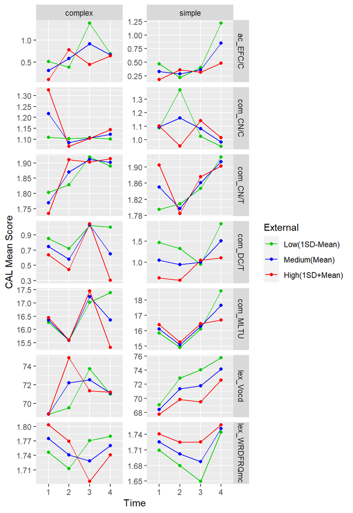

Figure 3. The impact of task repetition on CAL measures moderated by external motivation for simple and complex tasks

## 4.2 To what extent is that impact moderated by the level of task intrinsic motivation for simple and complex tasks?

The impact of task repetition on CAL measures moderated by intrinsic motivation for simple and complex tasks

intr

time

cal

task_dif

Mean

SE

Lower

Upper

t

p-value

Sig.

1.800

1

ac_EFC/C

complex

0.325

0.464

-0.597

1.246

0.699

0.486

3.000

1

ac_EFC/C

complex

0.441

0.249

-0.052

0.935

1.773

0.079

.

4.100

1

ac_EFC/C

complex

0.548

0.102

0.346

0.750

5.384

0.000

***

1.800

2

ac_EFC/C

complex

0.125

0.408

-0.684

0.934

0.307

0.760

3.000

2

ac_EFC/C

complex

0.240

0.222

-0.201

0.681

1.079

0.283

4.100

2

ac_EFC/C

complex

0.345

0.084

0.179

0.512

4.124

0.000

***

1.800

3

ac_EFC/C

complex

0.347

0.287

-0.222

0.916

1.211

0.229

3.000

3

ac_EFC/C

complex

0.937

0.112

0.715

1.159

8.362

0.000

***

4.100

3

ac_EFC/C

complex

1.477

0.105

1.270

1.685

14.133

0.000

***

1.800

4

ac_EFC/C

complex

0.932

0.287

0.361

1.502

3.240

0.002

3.000

4

ac_EFC/C

complex

0.775

0.122

0.533

1.016

6.359

0.000

***

4.100

4

ac_EFC/C

complex

0.631

0.086

0.460

0.801

7.339

0.000

***

1.800

1

com_CN/C

complex

1.066

0.199

0.672

1.461

5.362

0.000

***

3.000

1

com_CN/C

complex

1.076

0.107

0.864

1.287

10.099

0.000

***

4.100

1

com_CN/C

complex

1.084

0.044

0.998

1.171

24.928

0.000

***

1.800

2

com_CN/C

complex

1.229

0.173

0.885

1.573

7.089

0.000

***

3.000

2

com_CN/C

complex

1.169

0.095

0.981

1.357

12.366

0.000

***

4.100

2

com_CN/C

complex

1.114

0.036

1.044

1.185

31.381

0.000

***

1.800

3

com_CN/C

complex

0.990

0.121

0.750

1.230

8.184

0.000

***

3.000

3

com_CN/C

complex

1.069

0.047

0.975

1.163

22.642

0.000

***

4.100

3

com_CN/C

complex

1.142

0.044

1.054

1.229

25.916

0.000

***

1.800

4

com_CN/C

complex

1.075

0.121

0.835

1.315

8.877

0.000

***

3.000

4

com_CN/C

complex

1.096

0.051

0.994

1.198

21.383

0.000

***

4.100

4

com_CN/C

complex

1.116

0.036

1.044

1.187

30.880

0.000

***

1.800

1

com_CN/T

complex

1.887

0.100

1.688

2.086

18.799

0.000

***

3.000

1

com_CN/T

complex

1.849

0.054

1.743

1.956

34.392

0.000

***

4.100

1

com_CN/T

complex

1.815

0.022

1.771

1.858

82.633

0.000

***

1.800

2

com_CN/T

complex

1.757

0.087

1.583

1.930

20.079

0.000

***

3.000

2

com_CN/T

complex

1.789

0.048

1.695

1.884

37.493

0.000

***

4.100

2

com_CN/T

complex

1.819

0.018

1.784

1.855

101.480

0.000

***

1.800

3

com_CN/T

complex

1.959

0.061

1.838

2.080

32.087

0.000

***

3.000

3

com_CN/T

complex

1.930

0.024

1.883

1.977

80.982

0.000

***

4.100

3

com_CN/T

complex

1.904

0.022

1.860

1.948

85.610

0.000

***

1.800

4

com_CN/T

complex

1.867

0.061

1.746

1.989

30.547

0.000

***

3.000

4

com_CN/T

complex

1.884

0.026

1.833

1.935

72.807

0.000

***

4.100

4

com_CN/T

complex

1.900

0.018

1.863

1.936

104.157

0.000

***

1.800

1

com_DC/T

complex

0.774

0.562

-0.341

1.890

1.377

0.171

3.000

1

com_DC/T

complex

0.825

0.301

0.228

1.423

2.740

0.007

4.100

1

com_DC/T

complex

0.872

0.123

0.628

1.116

7.086

0.000

***

1.800

2

com_DC/T

complex

-0.276

0.490

-1.248

0.697

-0.563

0.575

3.000

2

com_DC/T

complex

0.207

0.267

-0.323

0.738

0.775

0.440

4.100

2

com_DC/T

complex

0.650

0.100

0.451

0.849

6.475

0.000

***

1.800

3

com_DC/T

complex

0.681

0.342

0.002

1.360

1.991

0.049

3.000

3

com_DC/T

complex

0.914

0.134

0.649

1.179

6.848

0.000

***

4.100

3

com_DC/T

complex

1.128

0.125

0.881

1.375

9.058

0.000

***

1.800

4

com_DC/T

complex

1.143

0.342

0.463

1.822

3.337

0.001

3.000

4

com_DC/T

complex

0.976

0.145

0.688

1.264

6.733

0.000

***

4.100

4

com_DC/T

complex

0.823

0.102

0.621

1.026

8.059

0.000

***

1.800

1

com_MLTU

complex

16.530

1.188

14.173

18.887

13.918

0.000

***

3.000

1

com_MLTU

complex

16.392

0.636

15.130

17.654

25.764

0.000

***

4.100

1

com_MLTU

complex

16.265

0.260

15.750

16.781

62.591

0.000

***

1.800

2

com_MLTU

complex

15.422

1.035

13.368

17.477

14.897

0.000

***

3.000

2

com_MLTU

complex

15.501

0.565

14.381

16.622

27.450

0.000

***

4.100

2

com_MLTU

complex

15.573

0.212

15.152

15.994

73.416

0.000

***

1.800

3

com_MLTU

complex

17.467

0.722

16.034

18.901

24.177

0.000

***

3.000

3

com_MLTU

complex

17.224

0.282

16.665

17.784

61.072

0.000

***

4.100

3

com_MLTU

complex

17.001

0.263

16.479

17.523

64.614

0.000

***

1.800

4

com_MLTU

complex

18.092

0.723

16.657

19.528

25.013

0.000

***

3.000

4

com_MLTU

complex

17.422

0.306

16.815

18.030

56.897

0.000

***

4.100

4

com_MLTU

complex

16.808

0.216

16.380

17.236

77.890

0.000

***

1.800

1

lex_Vocd

complex

68.530

6.780

55.078

81.983

10.108

0.000

***

3.000

1

lex_Vocd

complex

68.694

3.632

61.488

75.901

18.914

0.000

***

4.100

1

lex_Vocd

complex

68.845

1.483

65.901

71.788

46.410

0.000

***

1.800

2

lex_Vocd

complex

67.872

5.910

56.146

79.598

11.485

0.000

***

3.000

2

lex_Vocd

complex

68.563

3.223

62.167

74.959

21.270

0.000

***

4.100

2

lex_Vocd

complex

69.197

1.211

66.794

71.600

57.148

0.000

***

1.800

3

lex_Vocd

complex

75.289

4.124

67.106

83.472

18.256

0.000

***

3.000

3

lex_Vocd

complex

73.928

1.610

70.734

77.123

45.921

0.000

***

4.100

3

lex_Vocd

complex

72.681

1.502

69.700

75.661

48.391

0.000

***

1.800

4

lex_Vocd

complex

69.989

4.129

61.796

78.181

16.951

0.000

***

3.000

4

lex_Vocd

complex

70.657

1.748

67.189

74.125

40.423

0.000

***

4.100

4

lex_Vocd

complex

71.269

1.232

68.825

73.713

57.857

0.000

***

1.800

1

lex_WRDFRQmc

complex

1.768

0.094

1.580

1.955

18.719

0.000

***

3.000

1

lex_WRDFRQmc

complex

1.754

0.051

1.654

1.855

34.674

0.000

***

4.100

1

lex_WRDFRQmc

complex

1.742

0.021

1.701

1.783

84.290

0.000

***

1.800

2

lex_WRDFRQmc

complex

1.883

0.082

1.720

2.047

22.880

0.000

***

3.000

2

lex_WRDFRQmc

complex

1.800

0.045

1.711

1.889

40.096

0.000

***

4.100

2

lex_WRDFRQmc

complex

1.724

0.017

1.691

1.758

102.232

0.000

***

1.800

3

lex_WRDFRQmc

complex

1.704

0.057

1.590

1.818

29.666

0.000

***

3.000

3

lex_WRDFRQmc

complex

1.739

0.022

1.694

1.783

77.527

0.000

***

4.100

3

lex_WRDFRQmc

complex

1.770

0.021

1.729

1.812

84.607

0.000

***

1.800

4

lex_WRDFRQmc

complex

1.742

0.058

1.628

1.856

30.292

0.000

***

3.000

4

lex_WRDFRQmc

complex

1.762

0.024

1.713

1.810

72.351

0.000

***

4.100

4

lex_WRDFRQmc

complex

1.779

0.017

1.745

1.813

103.700

0.000

***

1.800

1

ac_EFC/C

simple

0.249

0.124

0.004

0.495

2.013

0.047

3.000

1

ac_EFC/C

simple

0.275

0.143

-0.009

0.560

1.921

0.058

.

4.100

1

ac_EFC/C

simple

0.299

0.283

-0.263

0.861

1.056

0.294

1.800

2

ac_EFC/C

simple

0.297

0.116

0.066

0.528

2.551

0.012

3.000

2

ac_EFC/C

simple

0.358

0.096

0.167

0.550

3.715

0.000

***

4.100

2

ac_EFC/C

simple

0.415

0.206

0.006

0.824

2.011

0.047

1.800

3

ac_EFC/C

simple

0.275

0.093

0.090

0.461

2.944

0.004

3.000

3

ac_EFC/C

simple

0.133

0.340

-0.542

0.808

0.391

0.697

4.100

3

ac_EFC/C

simple

0.003

0.583

-1.153

1.159

0.005

0.996

1.800

4

ac_EFC/C

simple

0.446

0.086

0.275

0.616

5.175

0.000

***

3.000

4

ac_EFC/C

simple

0.509

0.288

-0.062

1.079

1.770

0.080

.

4.100

4

ac_EFC/C

simple

0.567

0.488

-0.402

1.536

1.161

0.249

1.800

1

com_CN/C

simple

1.164

0.053

1.059

1.269

21.989

0.000

***

3.000

1

com_CN/C

simple

1.005

0.061

0.883

1.126

16.388

0.000

***

4.100

1

com_CN/C

simple

0.858

0.121

0.618

1.099

7.080

0.000

***

1.800

2

com_CN/C

simple

0.964

0.049

0.866

1.062

19.512

0.000

***

3.000

2

com_CN/C

simple

1.066

0.041

0.985

1.147

26.041

0.000

***

4.100

2

com_CN/C

simple

1.159

0.088

0.986

1.333

13.228

0.000

***

1.800

3

com_CN/C

simple

1.135

0.039

1.057

1.213

28.830

0.000

***

3.000

3

com_CN/C

simple

1.097

0.144

0.812

1.382

7.642

0.000

***

4.100

3

com_CN/C

simple

1.062

0.246

0.575

1.550

4.322

0.000

***

1.800

4

com_CN/C

simple

1.050

0.036

0.978

1.122

29.009

0.000

***

3.000

4

com_CN/C

simple

1.162

0.121

0.922

1.403

9.593

0.000

***

4.100

4

com_CN/C

simple

1.265

0.206

0.857

1.673

6.147

0.000

***

1.800

1

com_CN/T

simple

1.902

0.027

1.849

1.955

71.159

0.000

***

3.000

1

com_CN/T

simple

1.837

0.031

1.776

1.898

59.365

0.000

***

4.100

1

com_CN/T

simple

1.777

0.061

1.656

1.899

29.051

0.000

***

1.800

2

com_CN/T

simple

1.767

0.025

1.717

1.816

70.876

0.000

***

3.000

2

com_CN/T

simple

1.804

0.021

1.763

1.845

87.306

0.000

***

4.100

2

com_CN/T

simple

1.838

0.044

1.750

1.925

41.529

0.000

***

1.800

3

com_CN/T

simple

1.882

0.020

1.842

1.921

94.649

0.000

***

3.000

3

com_CN/T

simple

1.899

0.072

1.755

2.043

26.203

0.000

***

4.100

3

com_CN/T

simple

1.916

0.124

1.669

2.162

15.436

0.000

***

1.800

4

com_CN/T

simple

1.884

0.018

1.847

1.920

103.093

0.000

***

3.000

4

com_CN/T

simple

1.817

0.061

1.696

1.938

29.712

0.000

***

4.100

4

com_CN/T

simple

1.756

0.104

1.550

1.962

16.901

0.000

***

1.800

1

com_DC/T

simple

1.062

0.150

0.765

1.359

7.095

0.000

***

3.000

1

com_DC/T

simple

0.579

0.173

0.235

0.923

3.339

0.001

4.100

1

com_DC/T

simple

0.136

0.343

-0.544

0.816

0.396

0.693

1.800

2

com_DC/T

simple

0.532

0.140

0.254

0.809

3.807

0.000

***

3.000

2

com_DC/T

simple

0.814

0.116

0.584

1.043

7.030

0.000

***

4.100

2

com_DC/T

simple

1.072

0.248

0.580

1.564

4.325

0.000

***

1.800

3

com_DC/T

simple

1.098

0.111

0.877

1.319

9.860

0.000

***

3.000

3

com_DC/T

simple

1.273

0.406

0.467

2.078

3.134

0.002

4.100

3

com_DC/T

simple

1.432

0.695

0.053

2.812

2.061

0.042

1.800

4

com_DC/T

simple

1.085

0.102

0.882

1.288

10.605

0.000

***

3.000

4

com_DC/T

simple

1.233

0.343

0.553

1.912

3.599

0.001

***

4.100

4

com_DC/T

simple

1.368

0.582

0.213

2.523

2.350

0.021

1.800

1

com_MLTU

simple

15.988

0.316

15.360

16.616

50.552

0.000

***

3.000

1

com_MLTU

simple

16.586

0.366

15.859

17.312

45.297

0.000

***

4.100

1

com_MLTU

simple

17.133

0.724

15.697

18.570

23.665

0.000

***

1.800

2

com_MLTU

simple

14.932

0.295

14.347

15.517

50.620

0.000

***

3.000

2

com_MLTU

simple

15.378

0.244

14.893

15.864

62.906

0.000

***

4.100

2

com_MLTU

simple

15.788

0.524

14.749

16.827

30.154

0.000

***

1.800

3

com_MLTU

simple

16.322

0.235

15.855

16.789

69.386

0.000

***

3.000

3

com_MLTU

simple

15.769

0.858

14.068

17.471

18.386

0.000

***

4.100

3

com_MLTU

simple

15.263

1.468

12.349

18.176

10.394

0.000

***

1.800

4

com_MLTU

simple

16.566

0.216

16.137

16.995

76.628

0.000

***

3.000

4

com_MLTU

simple

16.607

0.724

15.171

18.043

22.951

0.000

***

4.100

4

com_MLTU

simple

16.644

1.229

14.205

19.084

13.540

0.000

***

1.800

1

lex_Vocd

simple

67.228

1.805

63.646

70.810

37.238

0.000

***

3.000

1

lex_Vocd

simple

69.373

2.090

65.226

73.521

33.191

0.000

***

4.100

1

lex_Vocd

simple

71.340

4.133

63.140

79.540

17.262

0.000

***

1.800

2

lex_Vocd

simple

71.558

1.684

68.217

74.899

42.498

0.000

***

3.000

2

lex_Vocd

simple

69.610

1.395

66.841

72.379

49.882

0.000

***

4.100

2

lex_Vocd

simple

67.825

2.989

61.895

73.755

22.693

0.000

***

1.800

3

lex_Vocd

simple

70.001

1.343

67.337

72.665

52.131

0.000

***

3.000

3

lex_Vocd

simple

72.811

4.896

63.096

82.526

14.872

0.000

***

4.100

3

lex_Vocd

simple

75.387

8.382

58.755

92.018

8.994

0.000

***

1.800

4

lex_Vocd

simple

71.013

1.234

68.564

73.462

57.543

0.000

***

3.000

4

lex_Vocd

simple

65.953

4.131

57.757

74.148

15.967

0.000

***

4.100

4

lex_Vocd

simple

61.314

7.017

47.391

75.237

8.738

0.000

***

1.800

1

lex_WRDFRQmc

simple

1.727

0.025

1.677

1.777

68.667

0.000

***

3.000

1

lex_WRDFRQmc

simple

1.739

0.029

1.681

1.797

59.739

0.000

***

4.100

1

lex_WRDFRQmc

simple

1.751

0.058

1.636

1.865

30.411

0.000

***

1.800

2

lex_WRDFRQmc

simple

1.696

0.023

1.649

1.742

72.289

0.000

***

3.000

2

lex_WRDFRQmc

simple

1.731

0.019

1.692

1.770

89.049

0.000

***

4.100

2

lex_WRDFRQmc

simple

1.764

0.042

1.681

1.846

42.360

0.000

***

1.800

3

lex_WRDFRQmc

simple

1.723

0.019

1.686

1.760

92.102

0.000

***

3.000

3

lex_WRDFRQmc

simple

1.698

0.068

1.563

1.834

24.903

0.000

***

4.100

3

lex_WRDFRQmc

simple

1.676

0.117

1.444

1.908

14.355

0.000

***

1.800

4

lex_WRDFRQmc

simple

1.755

0.017

1.721

1.790

102.117

0.000

***

3.000

4

lex_WRDFRQmc

simple

1.743

0.058

1.628

1.857

30.286

0.000

***

4.100

4

lex_WRDFRQmc

simple

1.731

0.098

1.537

1.925

17.707

0.000

***

Quantification of the model characteristics

| Terms | τ (SD) | ρ | σ (SD) |
| --- | --- | --- | --- |
| **Random-Effects’ Variation Across CALs** |  |  |  |
| ac_EFC/C | 0.108198 |  |  |
| com_CN/C | 0.000065 |  |  |
| com_CN/T | 0.000003 |  |  |
| com_DC/T | 0.000014 |  |  |
| com_MLTU | 0.000011 |  |  |
| lex_Vocd | 0.001352 |  |  |
| lex_WRDFRQmc | 0.000025 |  |  |
| **Residuals’ Common Corr. Across Participants** |  |  |  |
| Corr. Estimate |  | 0.010 |  |
| **Residuals’ Variation Across Times and CALs** |  |  |  |
| Time 1 |  |  | 1.797 |
| Time 2 |  |  | 1.573 |
| Time 3 |  |  | 1.445 |
| Time 4 |  |  | 1.423 |
| com_MLTU |  |  | 1.797 |
| com_DC/T |  |  | 1.236 |
| com_CN/T |  |  | 0.522 |
| com_CN/C |  |  | 0.735 |
| ac_EFC/C |  |  | 1.118 |
| lex_Vocd |  |  | 4.293 |
| lex_WRDFRQmc |  |  | 0.507 |

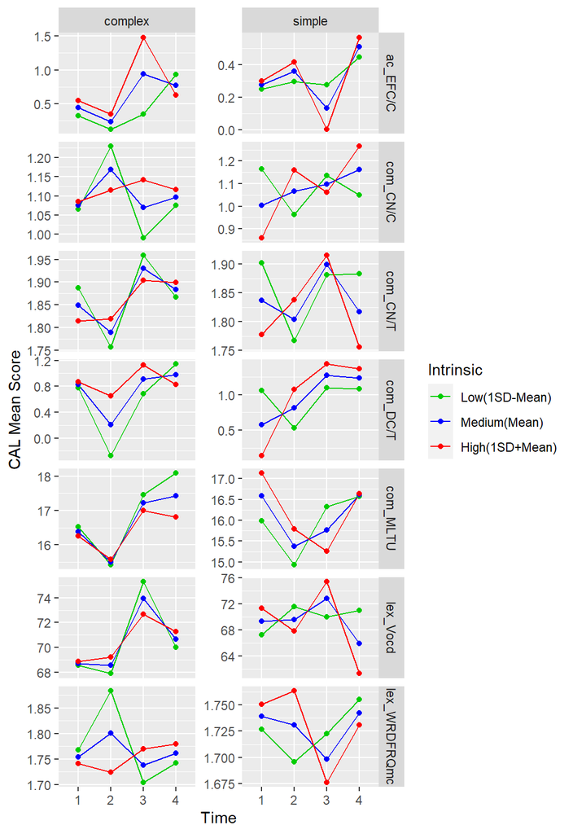

## 4.3 To what extent is that impact moderated by the level of task identified motivation for simple and complex tasks?

The impact of task repetition on CAL measures moderated by identified motivation for simple and complex tasks

iden

time

cal

task_dif

Mean

SE

Lower

Upper

t

p-value

Sig.

1.700

1

ac_EFC/C

complex

0.081

0.414

-0.741

0.902

0.195

0.846

2.800

1

ac_EFC/C

complex

0.320

0.224

-0.125

0.765

1.428

0.157

4.000

1

ac_EFC/C

complex

0.581

0.101

0.381

0.781

5.754

0.000

***

1.700

2

ac_EFC/C

complex

-0.425

0.372

-1.164

0.313

-1.143

0.256

2.800

2

ac_EFC/C

complex

-0.085

0.221

-0.524

0.354

-0.382

0.703

4.000

2

ac_EFC/C

complex

0.287

0.086

0.117

0.457

3.347

0.001

1.700

3

ac_EFC/C

complex

0.881

0.279

0.327

1.435

3.156

0.002

2.800

3

ac_EFC/C

complex

1.075

0.134

0.809

1.341

8.009

0.000

***

4.000

3

ac_EFC/C

complex

1.286

0.084

1.121

1.452

15.389

0.000

***

1.700

4

ac_EFC/C

complex

0.755

0.336

0.089

1.422

2.250

0.027

2.800

4

ac_EFC/C

complex

0.715

0.161

0.396

1.034

4.446

0.000

***

4.000

4

ac_EFC/C

complex

0.671

0.081

0.510

0.832

8.259

0.000

***

1.700

1

com_CN/C

complex

1.136

0.176

0.787

1.486

6.454

0.000

***

2.800

1

com_CN/C

complex

1.111

0.095

0.922

1.300

11.655

0.000

***

4.000

1

com_CN/C

complex

1.083

0.043

0.998

1.168

25.253

0.000

***

1.700

2

com_CN/C

complex

1.036

0.157

0.724

1.348

6.586

0.000

***

2.800

2

com_CN/C

complex

1.065

0.094

0.880

1.251

11.393

0.000

***

4.000

2

com_CN/C

complex

1.097

0.036

1.026

1.169

30.342

0.000

***

1.700

3

com_CN/C

complex

1.005

0.117

0.772

1.237

8.567

0.000

***

2.800

3

com_CN/C

complex

1.063

0.056

0.951

1.175

18.867

0.000

***

4.000

3

com_CN/C

complex

1.127

0.035

1.057

1.196

32.148

0.000

***

1.700

4

com_CN/C

complex

1.165

0.141

0.885

1.444

8.273

0.000

***

2.800

4

com_CN/C

complex

1.134

0.067

1.000

1.267

16.822

0.000

***

4.000

4

com_CN/C

complex

1.100

0.034

1.033

1.167

32.365

0.000

***

1.700

1

com_CN/T

complex

1.847

0.088

1.671

2.022

20.868

0.000

***

2.800

1

com_CN/T

complex

1.829

0.048

1.734

1.924

38.180

0.000

***

4.000

1

com_CN/T

complex

1.810

0.022

1.767

1.852

83.953

0.000

***

1.700

2

com_CN/T

complex

1.815

0.079

1.658

1.972

22.957

0.000

***

2.800

2

com_CN/T

complex

1.819

0.047

1.726

1.912

38.711

0.000

***

4.000

2

com_CN/T

complex

1.824

0.018

1.788

1.860

100.344

0.000

***

1.700

3

com_CN/T

complex

1.944

0.059

1.827

2.061

32.990

0.000

***

2.800

3

com_CN/T

complex

1.928

0.028

1.872

1.984

68.098

0.000

***

4.000

3

com_CN/T

complex

1.911

0.018

1.876

1.946

108.484

0.000

***

1.700

4

com_CN/T

complex

1.824

0.071

1.683

1.964

25.777

0.000

***

2.800

4

com_CN/T

complex

1.863

0.034

1.795

1.930

54.990

0.000

***

4.000

4

com_CN/T

complex

1.905

0.017

1.871

1.939

111.516

0.000

***

1.700

1

com_DC/T

complex

0.231

0.503

-0.766

1.228

0.460

0.647

2.800

1

com_DC/T

complex

0.554

0.272

0.014

1.094

2.036

0.044

4.000

1

com_DC/T

complex

0.906

0.122

0.663

1.149

7.400

0.000

***

1.700

2

com_DC/T

complex

0.215

0.449

-0.676

1.106

0.478

0.634

2.800

2

com_DC/T

complex

0.438

0.267

-0.091

0.968

1.642

0.104

4.000

2

com_DC/T

complex

0.682

0.103

0.477

0.887

6.607

0.000

***

1.700

3

com_DC/T

complex

1.310

0.335

0.646

1.975

3.916

0.000

***

2.800

3

com_DC/T

complex

1.149

0.161

0.830

1.468

7.147

0.000

***

4.000

3

com_DC/T

complex

0.973

0.100

0.775

1.172

9.731

0.000

***

1.700

4

com_DC/T

complex

1.336

0.402

0.539

2.133

3.326

0.001

2.800

4

com_DC/T

complex

1.083

0.192

0.702

1.465

5.632

0.000

***

4.000

4

com_DC/T

complex

0.807

0.097

0.615

1.000

8.323

0.000

***

1.700

1

com_MLTU

complex

15.483

1.059

13.381

17.585

14.617

0.000

***

2.800

1

com_MLTU

complex

15.868

0.573

14.730

17.005

27.673

0.000

***

4.000

1

com_MLTU

complex

16.287

0.258

15.775

16.799

63.125

0.000

***

1.700

2

com_MLTU

complex

15.691

0.946

13.814

17.569

16.581

0.000

***

2.800

2

com_MLTU

complex

15.646

0.563

14.530

16.762

27.813

0.000

***

4.000

2

com_MLTU

complex

15.597

0.218

15.165

16.029

71.688

0.000

***

1.700

3

com_MLTU

complex

17.436

0.705

16.036

18.835

24.716

0.000

***

2.800

3

com_MLTU

complex

17.248

0.339

16.576

17.921

50.888

0.000

***

4.000

3

com_MLTU

complex

17.044

0.211

16.626

17.463

80.835

0.000

***

1.700

4

com_MLTU

complex

16.861

0.847

15.181

18.542

19.909

0.000

***

2.800

4

com_MLTU

complex

16.953

0.405

16.149

17.758

41.814

0.000

***

4.000

4

com_MLTU

complex

17.053

0.204

16.648

17.459

83.405

0.000

***

1.700

1

lex_Vocd

complex

70.966

6.017

59.027

82.905

11.794

0.000

***

2.800

1

lex_Vocd

complex

69.913

3.257

63.450

76.376

21.464

0.000

***

4.000

1

lex_Vocd

complex

68.764

1.466

65.856

71.673

46.917

0.000

***

1.700

2

lex_Vocd

complex

71.792

5.376

61.125

82.458

13.355

0.000

***

2.800

2

lex_Vocd

complex

70.725

3.196

64.384

77.066

22.133

0.000

***

4.000

2

lex_Vocd

complex

69.562

1.236

67.109

72.014

56.285

0.000

***

1.700

3

lex_Vocd

complex

74.569

4.007

66.618

82.520

18.609

0.000

***

2.800

3

lex_Vocd

complex

73.830

1.925

70.010

77.651

38.346

0.000

***

4.000

3

lex_Vocd

complex

73.024

1.198

70.647

75.401

60.969

0.000

***

1.700

4

lex_Vocd

complex

66.799

4.811

57.253

76.344

13.885

0.000

***

2.800

4

lex_Vocd

complex

69.145

2.303

64.575

73.715

30.023

0.000

***

4.000

4

lex_Vocd

complex

71.704

1.161

69.400

74.009

61.736

0.000

***

1.700

1

lex_WRDFRQmc

complex

1.787

0.084

1.621

1.952

21.395

0.000

***

2.800

1

lex_WRDFRQmc

complex

1.764

0.045

1.674

1.853

39.011

0.000

***

4.000

1

lex_WRDFRQmc

complex

1.738

0.020

1.698

1.779

85.454

0.000

***

1.700

2

lex_WRDFRQmc

complex

1.757

0.075

1.609

1.906

23.555

0.000

***

2.800

2

lex_WRDFRQmc

complex

1.737

0.044

1.649

1.825

39.166

0.000

***

4.000

2

lex_WRDFRQmc

complex

1.715

0.017

1.681

1.749

99.966

0.000

***

1.700

3

lex_WRDFRQmc

complex

1.806

0.056

1.696

1.916

32.472

0.000

***

2.800

3

lex_WRDFRQmc

complex

1.777

0.027

1.724

1.830

66.501

0.000

***

4.000

3

lex_WRDFRQmc

complex

1.746

0.017

1.713

1.779

105.007

0.000

***

1.700

4

lex_WRDFRQmc

complex

1.613

0.067

1.481

1.746

24.159

0.000

***

2.800

4

lex_WRDFRQmc

complex

1.701

0.032

1.638

1.765

53.226

0.000

***

4.000

4

lex_WRDFRQmc

complex

1.798

0.016

1.766

1.830

111.514

0.000

***

1.700

1

ac_EFC/C

simple

0.268

0.120

0.030

0.507

2.233

0.028

2.800

1

ac_EFC/C

simple

0.244

0.162

-0.078

0.566

1.506

0.135

4.000

1

ac_EFC/C

simple

0.218

0.356

-0.489

0.926

0.613

0.541

1.700

2

ac_EFC/C

simple

0.323

0.108

0.109

0.536

2.998

0.003

2.800

2

ac_EFC/C

simple

0.342

0.095

0.153

0.531

3.596

0.001

***

4.000

2

ac_EFC/C

simple

0.363

0.211

-0.055

0.781

1.725

0.088

.

1.700

3

ac_EFC/C

simple

0.292

0.088

0.118

0.466

3.334

0.001

2.800

3

ac_EFC/C

simple

0.218

0.292

-0.361

0.798

0.748

0.456

4.000

3

ac_EFC/C

simple

0.138

0.536

-0.926

1.202

0.258

0.797

1.700

4

ac_EFC/C

simple

0.402

0.078

0.247

0.557

5.146

0.000

***

2.800

4

ac_EFC/C

simple

0.297

0.234

-0.167

0.760

1.269

0.208

4.000

4

ac_EFC/C

simple

0.181

0.425

-0.663

1.026

0.427

0.671

1.700

1

com_CN/C

simple

1.161

0.051

1.059

1.262

22.721

0.000

***

2.800

1

com_CN/C

simple

0.978

0.069

0.841

1.115

14.181

0.000

***

4.000

1

com_CN/C

simple

0.779

0.152

0.479

1.080

5.142

0.000

***

1.700

2

com_CN/C

simple

1.042

0.045

0.951

1.132

22.927

0.000

***

2.800

2

com_CN/C

simple

1.013

0.040

0.933

1.092

25.220

0.000

***

4.000

2

com_CN/C

simple

0.981

0.089

0.804

1.158

11.018

0.000

***

1.700

3

com_CN/C

simple

1.116

0.037

1.044

1.189

30.391

0.000

***

2.800

3

com_CN/C

simple

1.005

0.123

0.761

1.248

8.190

0.000

***

4.000

3

com_CN/C

simple

0.883

0.225

0.436

1.330

3.920

0.000

***

1.700

4

com_CN/C

simple

1.053

0.033

0.988

1.118

32.201

0.000

***

2.800

4

com_CN/C

simple

1.180

0.098

0.985

1.374

12.038

0.000

***

4.000

4

com_CN/C

simple

1.318

0.178

0.964

1.672

7.389

0.000

***

1.700

1

com_CN/T

simple

1.927

0.026

1.876

1.978

75.044

0.000

***

2.800

1

com_CN/T

simple

1.777

0.035

1.708

1.846

51.249

0.000

***

4.000

1

com_CN/T

simple

1.614

0.076

1.463

1.765

21.184

0.000

***

1.700

2

com_CN/T

simple

1.801

0.023

1.756

1.847

78.900

0.000

***

2.800

2

com_CN/T

simple

1.780

0.020

1.740

1.820

88.206

0.000

***

4.000

2

com_CN/T

simple

1.756

0.045

1.667

1.845

39.252

0.000

***

1.700

3

com_CN/T

simple

1.877

0.018

1.841

1.914

101.676

0.000

***

2.800

3

com_CN/T

simple

1.877

0.062

1.755

1.999

30.442

0.000

***

4.000

3

com_CN/T

simple

1.877

0.113

1.652

2.101

16.583

0.000

***

1.700

4

com_CN/T

simple

1.897

0.016

1.864

1.929

115.418

0.000

***

2.800

4

com_CN/T

simple

1.879

0.049

1.782

1.977

38.161

0.000

***

4.000

4

com_CN/T

simple

1.860

0.090

1.683

2.038

20.756

0.000

***

1.700

1

com_DC/T

simple

0.966

0.146

0.677

1.256

6.629

0.000

***

2.800

1

com_DC/T

simple

0.661

0.197

0.270

1.052

3.356

0.001

4.000

1

com_DC/T

simple

0.327

0.433

-0.531

1.186

0.757

0.451

1.700

2

com_DC/T

simple

0.659

0.130

0.402

0.917

5.085

0.000

***

2.800

2

com_DC/T

simple

0.731

0.115

0.504

0.959

6.382

0.000

***

4.000

2

com_DC/T

simple

0.810

0.254

0.306

1.314

3.187

0.002

1.700

3

com_DC/T

simple

1.045

0.105

0.837

1.253

9.969

0.000

***

2.800

3

com_DC/T

simple

1.009

0.350

0.314

1.704

2.882

0.005

4.000

3

com_DC/T

simple

0.970

0.643

-0.305

2.245

1.509

0.134

1.700

4

com_DC/T

simple

1.014

0.093

0.829

1.199

10.869

0.000

***

2.800

4

com_DC/T

simple

0.886

0.280

0.332

1.441

3.170

0.002

4.000

4

com_DC/T

simple

0.747

0.509

-0.263

1.757

1.467

0.145

1.700

1

com_MLTU

simple

16.184

0.307

15.574

16.794

52.664

0.000

***

2.800

1

com_MLTU

simple

16.337

0.415

15.513

17.161

39.361

0.000

***

4.000

1

com_MLTU

simple

16.504

0.912

14.694

18.313

18.098

0.000

***

1.700

2

com_MLTU

simple

15.117

0.273

14.575

15.659

55.310

0.000

***

2.800

2

com_MLTU

simple

15.261

0.242

14.781

15.740

63.182

0.000

***

4.000

2

com_MLTU

simple

15.417

0.536

14.355

16.480

28.788

0.000

***

1.700

3

com_MLTU

simple

16.473

0.221

16.034

16.911

74.538

0.000

***

2.800

3

com_MLTU

simple

16.522

0.738

15.057

17.986

22.386

0.000

***

4.000

3

com_MLTU

simple

16.576

1.355

13.888

19.263

12.236

0.000

***

1.700

4

com_MLTU

simple

16.664

0.197

16.274

17.055

84.720

0.000

***

2.800

4

com_MLTU

simple

17.091

0.589

15.921

18.261

28.993

0.000

***

4.000

4

com_MLTU

simple

17.556

1.073

15.427

19.685

16.363

0.000

***

1.700

1

lex_Vocd

simple

67.081

1.746

63.618

70.545

38.427

0.000

***

2.800

1

lex_Vocd

simple

70.093

2.358

65.415

74.772

29.729

0.000

***

4.000

1

lex_Vocd

simple

73.379

5.180

63.101

83.658

14.166

0.000

***

1.700

2

lex_Vocd

simple

69.445

1.553

66.364

72.526

44.729

0.000

***

2.800

2

lex_Vocd

simple

71.086

1.372

68.363

73.808

51.811

0.000

***

4.000

2

lex_Vocd

simple

72.876

3.042

66.839

78.912

23.955

0.000

***

1.700

3

lex_Vocd

simple

70.042

1.255

67.551

72.533

55.794

0.000

***

2.800

3

lex_Vocd

simple

72.963

4.192

64.645

81.282

17.404

0.000

***

4.000

3

lex_Vocd

simple

76.150

7.695

60.881

91.419

9.896

0.000

***

1.700

4

lex_Vocd

simple

72.641

1.117

70.423

74.858

65.011

0.000

***

2.800

4

lex_Vocd

simple

73.843

3.349

67.199

80.488

22.052

0.000

***

4.000

4

lex_Vocd

simple

75.155

6.095

63.062

87.249

12.331

0.000

***

1.700

1

lex_WRDFRQmc

simple

1.720

0.024

1.672

1.768

71.007

0.000

***

2.800

1

lex_WRDFRQmc

simple

1.754

0.033

1.689

1.819

53.603

0.000

***

4.000

1

lex_WRDFRQmc

simple

1.791

0.072

1.648

1.933

24.909

0.000

***

1.700

2

lex_WRDFRQmc

simple

1.702

0.022

1.659

1.744

78.971

0.000

***

2.800

2

lex_WRDFRQmc

simple

1.728

0.019

1.690

1.766

90.742

0.000

***

4.000

2

lex_WRDFRQmc

simple

1.757

0.042

1.673

1.840

41.604

0.000

***

1.700

3

lex_WRDFRQmc

simple

1.733

0.017

1.699

1.768

99.484

0.000

***

2.800

3

lex_WRDFRQmc

simple

1.751

0.058

1.636

1.867

30.095

0.000

***

4.000

3

lex_WRDFRQmc

simple

1.770

0.107

1.559

1.982

16.578

0.000

***

1.700

4

lex_WRDFRQmc

simple

1.753

0.016

1.722

1.784

113.041

0.000

***

2.800

4

lex_WRDFRQmc

simple

1.730

0.046

1.638

1.822

37.230

0.000

***

4.000

4

lex_WRDFRQmc

simple

1.705

0.085

1.538

1.873

20.162

0.000

***

Quantification of the model characteristics

| Terms | τ (SD) | ρ | σ (SD) |
| --- | --- | --- | --- |
| **Random-Effects’ Variation Across CALs** |  |  |  |
| ac_EFC/C | 0.102218 |  |  |
| com_CN/C | 0.000055 |  |  |
| com_CN/T | 0.000004 |  |  |
| com_DC/T | 0.000011 |  |  |
| com_MLTU | 0.000011 |  |  |
| lex_Vocd | 0.000950 |  |  |
| lex_WRDFRQmc | 0.000021 |  |  |
| **Residuals’ Common Corr. Across Participants** |  |  |  |
| Corr. Estimate |  | 0.007 |  |
| **Residuals’ Variation Across Times and CALs** |  |  |  |
| Time 1 |  |  | 1.794 |
| Time 2 |  |  | 1.582 |
| Time 3 |  |  | 1.451 |
| Time 4 |  |  | 1.422 |
| com_MLTU |  |  | 1.794 |
| com_DC/T |  |  | 1.236 |
| com_CN/T |  |  | 0.519 |
| com_CN/C |  |  | 0.732 |
| ac_EFC/C |  |  | 1.117 |
| lex_Vocd |  |  | 4.276 |
| lex_WRDFRQmc |  |  | 0.504 |

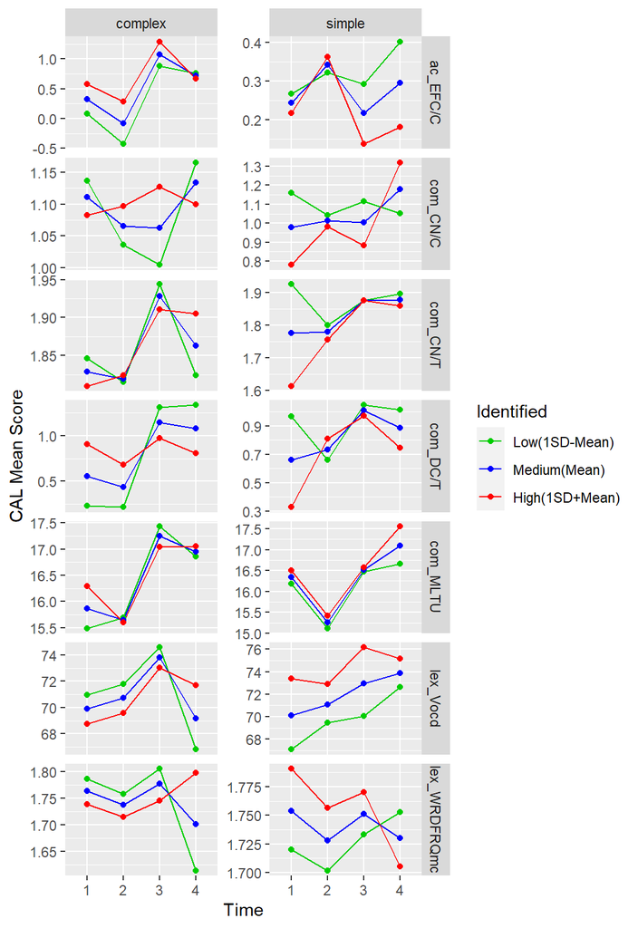

Figure 4. The impact of task repetition on CAL measures moderated by identified motivation for simple and complex tasks

## 4.4 To what extent is that impact moderated by the level of task amotivation for simple and complex tasks?

The impact of task repetition on CAL measures moderated by amotivation for simple and complex tasks

amot

time

cal

task_dif

Mean

SE

Lower

Upper

t

p-value

Sig.

2.100

1

ac_EFC/C

complex

0.534

0.103

0.331

0.738

5.209

0.000

***

3.200

1

ac_EFC/C

complex

0.329

0.248

-0.164

0.822

1.325

0.188

4.300

1

ac_EFC/C

complex

0.124

0.442

-0.753

1.001

0.280

0.780

2.100

2

ac_EFC/C

complex

0.374

0.077

0.220

0.528

4.829

0.000

***

3.200

2

ac_EFC/C

complex

0.583

0.207

0.172

0.994

2.816

0.006

4.300

2

ac_EFC/C

complex

0.792

0.384

0.029

1.554

2.061

0.042

2.100

3

ac_EFC/C

complex

1.429

0.097

1.235

1.622

14.660

0.000

***

3.200

3

ac_EFC/C

complex

0.904

0.129

0.648

1.160

7.002

0.000

***

4.300

3

ac_EFC/C

complex

0.379

0.302

-0.221

0.979

1.254

0.213

2.100

4

ac_EFC/C

complex

0.753

0.090

0.574

0.931

8.369

0.000

***

3.200

4

ac_EFC/C

complex

0.552

0.134

0.287

0.817

4.134

0.000

***

4.300

4

ac_EFC/C

complex

0.352

0.305

-0.254

0.957

1.151

0.252

2.100

1

com_CN/C

complex

1.083

0.044

0.996

1.170

24.692

0.000

***

3.200

1

com_CN/C

complex

1.060

0.106

0.849

1.271

9.966

0.000

***

4.300

1

com_CN/C

complex

1.037

0.189

0.661

1.412

5.480

0.000

***

2.100

2

com_CN/C

complex

1.107

0.033

1.041

1.172

33.658

0.000

***

3.200

2

com_CN/C

complex

1.169

0.088

0.994

1.343

13.277

0.000

***

4.300

2

com_CN/C

complex

1.231

0.163

0.906

1.555

7.530

0.000

***

2.100

3

com_CN/C

complex

1.116

0.041

1.035

1.198

27.131

0.000

***

3.200

3

com_CN/C

complex

1.093

0.055

0.985

1.202

20.046

0.000

***

4.300

3

com_CN/C

complex

1.070

0.128

0.817

1.324

8.373

0.000

***

2.100

4

com_CN/C

complex

1.115

0.038

1.040

1.190

29.404

0.000

***

3.200

4

com_CN/C

complex

1.097

0.056

0.985

1.209

19.467

0.000

***

4.300

4

com_CN/C

complex

1.079

0.129

0.823

1.335

8.371

0.000

***

2.100

1

com_CN/T

complex

1.804

0.022

1.761

1.848

82.376

0.000

***

3.200

1

com_CN/T

complex

1.748

0.053

1.643

1.854

32.915

0.000

***

4.300

1

com_CN/T

complex

1.693

0.095

1.505

1.880

17.906

0.000

***

2.100

2

com_CN/T

complex

1.826

0.016

1.793

1.858

111.209

0.000

***

3.200

2

com_CN/T

complex

1.850

0.044

1.762

1.937

42.081

0.000

***

4.300

2

com_CN/T

complex

1.874

0.082

1.712

2.035

22.958

0.000

***

2.100

3

com_CN/T

complex

1.910

0.021

1.869

1.951

93.020

0.000

***

3.200

3

com_CN/T

complex

1.926

0.027

1.872

1.980

70.761

0.000

***

4.300

3

com_CN/T

complex

1.942

0.064

1.815

2.068

30.441

0.000

***

2.100

4

com_CN/T

complex

1.892

0.019

1.854

1.929

99.994

0.000

***

3.200

4

com_CN/T

complex

1.898

0.028

1.842

1.954

67.505

0.000

***

4.300

4

com_CN/T

complex

1.904

0.064

1.777

2.032

29.607

0.000

***

2.100

1

com_DC/T

complex

0.849

0.125

0.601

1.097

6.796

0.000

***

3.200

1

com_DC/T

complex

0.620

0.303

0.019

1.221

2.046

0.043

4.300

1

com_DC/T

complex

0.391

0.539

-0.679

1.460

0.725

0.470

2.100

2

com_DC/T

complex

0.727

0.094

0.542

0.913

7.772

0.000

***

3.200

2

com_DC/T

complex

0.588

0.251

0.091

1.085

2.346

0.021

4.300

2

com_DC/T

complex

0.448

0.465

-0.475

1.372

0.964

0.337

2.100

3

com_DC/T

complex

1.114

0.117

0.881

1.346

9.513

0.000

***

3.200

3

com_DC/T

complex

0.894

0.155

0.586

1.202

5.762

0.000

***

4.300

3

com_DC/T

complex

0.675

0.364

-0.047

1.396

1.855

0.067

.

2.100

4

com_DC/T

complex

0.960

0.108

0.746

1.174

8.900

0.000

***

3.200

4

com_DC/T

complex

0.726

0.160

0.408

1.045

4.532

0.000

***

4.300

4

com_DC/T

complex

0.493

0.367

-0.235

1.221

1.344

0.182

2.100

1

com_MLTU

complex

16.281

0.263

15.760

16.802

61.998

0.000

***

3.200

1

com_MLTU

complex

16.517

0.637

15.253

17.780

25.935

0.000

***

4.300

1

com_MLTU

complex

16.752

1.133

14.504

19.001

14.784

0.000

***

2.100

2

com_MLTU

complex

15.575

0.197

15.184

15.965

79.128

0.000

***

3.200

2

com_MLTU

complex

15.290

0.527

14.244

16.335

29.015

0.000

***

4.300

2

com_MLTU

complex

15.005

0.978

13.064

16.946

15.337

0.000

***

2.100

3

com_MLTU

complex

17.147

0.246

16.658

17.635

69.659

0.000

***

3.200

3

com_MLTU

complex

17.045

0.326

16.398

17.692

52.238

0.000

***

4.300

3

com_MLTU

complex

16.943

0.765

15.426

18.461

22.155

0.000

***

2.100

4

com_MLTU

complex

17.089

0.227

16.639

17.539

75.347

0.000

***

3.200

4

com_MLTU

complex

16.914

0.337

16.245

17.583

50.175

0.000

***

4.300

4

com_MLTU

complex

16.739

0.771

15.209

18.269

21.706

0.000

***

2.100

1

lex_Vocd

complex

68.647

1.490

65.691

71.604

46.075

0.000

***

3.200

1

lex_Vocd

complex

66.891

3.613

59.721

74.060

18.513

0.000

***

4.300

1

lex_Vocd

complex

65.134

6.429

52.378

77.891

10.131

0.000

***

2.100

2

lex_Vocd

complex

69.475

1.117

67.259

71.691

62.213

0.000

***

3.200

2

lex_Vocd

complex

73.218

2.990

67.285

79.150

24.489

0.000

***

4.300

2

lex_Vocd

complex

76.960

5.551

65.946

87.974

13.865

0.000

***

2.100

3

lex_Vocd

complex

74.305

1.397

71.534

77.076

53.205

0.000

***

3.200

3

lex_Vocd

complex

71.678

1.851

68.005

75.352

38.719

0.000

***

4.300

3

lex_Vocd

complex

69.051

4.339

60.442

77.661

15.914

0.000

***

2.100

4

lex_Vocd

complex

71.907

1.287

69.354

74.460

55.879

0.000

***

3.200

4

lex_Vocd

complex

69.470

1.913

65.675

73.265

36.323

0.000

***

4.300

4

lex_Vocd

complex

67.033

4.375

58.351

75.714

15.321

0.000

***

2.100

1

lex_WRDFRQmc

complex

1.741

0.021

1.699

1.782

83.169

0.000

***

3.200

1

lex_WRDFRQmc

complex

1.745

0.051

1.644

1.846

34.373

0.000

***

4.300

1

lex_WRDFRQmc

complex

1.749

0.090

1.570

1.928

19.362

0.000

***

2.100

2

lex_WRDFRQmc

complex

1.711

0.016

1.679

1.742

109.032

0.000

***

3.200

2

lex_WRDFRQmc

complex

1.724

0.042

1.641

1.808

41.051

0.000

***

4.300

2

lex_WRDFRQmc

complex

1.738

0.078

1.583

1.893

22.287

0.000

***

2.100

3

lex_WRDFRQmc

complex

1.777

0.020

1.738

1.816

90.550

0.000

***

3.200

3

lex_WRDFRQmc

complex

1.722

0.026

1.671

1.774

66.219

0.000

***

4.300

3

lex_WRDFRQmc

complex

1.668

0.061

1.547

1.789

27.360

0.000

***

2.100

4

lex_WRDFRQmc

complex

1.767

0.018

1.731

1.803

97.741

0.000

***

3.200

4

lex_WRDFRQmc

complex

1.784

0.027

1.731

1.837

66.395

0.000

***

4.300

4

lex_WRDFRQmc

complex

1.801

0.061

1.679

1.923

29.300

0.000

***

2.100

1

ac_EFC/C

simple

0.478

0.369

-0.254

1.210

1.295

0.198

3.200

1

ac_EFC/C

simple

0.341

0.166

0.012

0.670

2.059

0.042

4.300

1

ac_EFC/C

simple

0.205

0.135

-0.062

0.472

1.521

0.131

2.100

2

ac_EFC/C

simple

0.168

0.293

-0.413

0.749

0.574

0.567

3.200

2

ac_EFC/C

simple

0.263

0.144

-0.022

0.548

1.829

0.070

.

4.300

2

ac_EFC/C

simple

0.357

0.087

0.185

0.530

4.112

0.000

***

2.100

3

ac_EFC/C

simple

0.357

0.434

-0.505

1.218

0.821

0.414

3.200

3

ac_EFC/C

simple

0.335

0.234

-0.130

0.800

1.428

0.156

4.300

3

ac_EFC/C

simple

0.313

0.069

0.177

0.449

4.569

0.000

***

2.100

4

ac_EFC/C

simple

0.485

0.495

-0.497

1.466

0.980

0.330

3.200

4

ac_EFC/C

simple

0.459

0.271

-0.078

0.996

1.695

0.093

.

4.300

4

ac_EFC/C

simple

0.433

0.073

0.288

0.578

5.940

0.000

***

2.100

1

com_CN/C

simple

1.140

0.158

0.827

1.453

7.221

0.000

***

3.200

1

com_CN/C

simple

1.114

0.071

0.973

1.254

15.715

0.000

***

4.300

1

com_CN/C

simple

1.087

0.058

0.973

1.201

18.888

0.000

***

2.100

2

com_CN/C

simple

1.337

0.125

1.090

1.584

10.735

0.000

***

3.200

2

com_CN/C

simple

1.159

0.061

1.038

1.280

18.977

0.000

***

4.300

2

com_CN/C

simple

0.981

0.037

0.907

1.054

26.583

0.000

***

2.100

3

com_CN/C

simple

1.161

0.184

0.796

1.525

6.320

0.000

***

3.200

3

com_CN/C

simple

1.153

0.099

0.956

1.350

11.634

0.000

***

4.300

3

com_CN/C

simple

1.146

0.029

1.088

1.203

39.661

0.000

***

2.100

4

com_CN/C

simple

0.800

0.209

0.385

1.214

3.829

0.000

***

3.200

4

com_CN/C

simple

0.902

0.114

0.675

1.129

7.892

0.000

***

4.300

4

com_CN/C

simple

1.004

0.031

0.944

1.065

32.704

0.000

***

2.100

1

com_CN/T

simple

1.621

0.079

1.464

1.777

20.547

0.000

***

3.200

1

com_CN/T

simple

1.780

0.035

1.710

1.850

50.286

0.000

***

4.300

1

com_CN/T

simple

1.940

0.029

1.883

1.997

67.465

0.000

***

2.100

2

com_CN/T

simple

1.831

0.062

1.707

1.954

29.441

0.000

***

3.200

2

com_CN/T

simple

1.807

0.030

1.746

1.867

59.264

0.000

***

4.300

2

com_CN/T

simple

1.783

0.018

1.747

1.820

96.806

0.000

***

2.100

3

com_CN/T

simple

1.764

0.092

1.582

1.946

19.249

0.000

***

3.200

3

com_CN/T

simple

1.818

0.049

1.720

1.916

36.751

0.000

***

4.300

3

com_CN/T

simple

1.872

0.014

1.843

1.900

129.850

0.000

***

2.100

4

com_CN/T

simple

1.920

0.104

1.713

2.126

18.421

0.000

***

3.200

4

com_CN/T

simple

1.911

0.057

1.798

2.024

33.508

0.000

***

4.300

4

com_CN/T

simple

1.902

0.015

1.872

1.933

124.136

0.000

***

2.100

1

com_DC/T

simple

1.331

0.450

0.439

2.224

2.960

0.004

3.200

1

com_DC/T

simple

1.036

0.202

0.636

1.437

5.134

0.000

***

4.300

1

com_DC/T

simple

0.741

0.164

0.416

1.066

4.521

0.000

***

2.100

2

com_DC/T

simple

1.345

0.355

0.641

2.048

3.793

0.000

***

3.200

2

com_DC/T

simple

0.977

0.174

0.632

1.322

5.621

0.000

***

4.300

2

com_DC/T

simple

0.609

0.105

0.401

0.818

5.803

0.000

***

2.100

3

com_DC/T

simple

1.145

0.522

0.109

2.182

2.192

0.031

3.200

3

com_DC/T

simple

1.102

0.282

0.543

1.662

3.908

0.000

***

4.300

3

com_DC/T

simple

1.059

0.082

0.896

1.222

12.885

0.000

***

2.100

4

com_DC/T

simple

0.926

0.594

-0.253

2.105

1.558

0.122

3.200

4

com_DC/T

simple

0.982

0.325

0.337

1.627

3.020

0.003

4.300

4

com_DC/T

simple

1.038

0.087

0.865

1.211

11.881

0.000

***

2.100

1

com_MLTU

simple

15.926

0.946

14.049

17.802

16.841

0.000

***

3.200

1

com_MLTU

simple

16.121

0.424

15.279

16.963

37.984

0.000

***

4.300

1

com_MLTU

simple

16.316

0.345

15.632

17.000

47.338

0.000

***

2.100

2

com_MLTU

simple

15.084

0.746

13.605

16.564

20.232

0.000

***

3.200

2

com_MLTU

simple

15.150

0.366

14.425

15.876

41.447

0.000

***

4.300

2

com_MLTU

simple

15.216

0.221

14.778

15.654

68.909

0.000

***

2.100

3

com_MLTU

simple

15.701

1.099

13.521

17.881

14.291

0.000

***

3.200

3

com_MLTU

simple

16.062

0.593

14.885

17.239

27.086

0.000

***

4.300

3

com_MLTU

simple

16.423

0.173

16.080

16.766

95.038

0.000

***

2.100

4

com_MLTU

simple

18.575

1.249

16.096

21.054

14.868

0.000

***

3.200

4

com_MLTU

simple

17.639

0.684

16.283

18.996

25.799

0.000

***

4.300

4

com_MLTU

simple

16.703

0.184

16.339

17.068

90.916

0.000

***

2.100

1

lex_Vocd

simple

65.709

5.365

55.063

76.355

12.247

0.000

***

3.200

1

lex_Vocd

simple

67.223

2.408

62.445

72.001

27.917

0.000

***

4.300

1

lex_Vocd

simple

68.737

1.956

64.857

72.617

35.150

0.000

***

2.100

2

lex_Vocd

simple

70.682

4.230

62.289

79.075

16.710

0.000

***

3.200

2

lex_Vocd

simple

70.515

2.074

66.400

74.630

34.001

0.000

***

4.300

2

lex_Vocd

simple

70.348

1.253

67.862

72.834

56.151

0.000

***

2.100

3

lex_Vocd

simple

78.096

6.233

65.727

90.464

12.529

0.000

***

3.200

3

lex_Vocd

simple

73.913

3.364

67.237

80.588

21.969

0.000

***

4.300

3

lex_Vocd

simple

69.730

0.980

67.784

71.675

71.122

0.000

***

2.100

4

lex_Vocd

simple

77.626

7.088

63.562

91.690

10.952

0.000

***

3.200

4

lex_Vocd

simple

75.174

3.879

67.476

82.871

19.379

0.000

***

4.300

4

lex_Vocd

simple

72.721

1.042

70.653

74.789

69.765

0.000

***

2.100

1

lex_WRDFRQmc

simple

1.721

0.075

1.572

1.871

22.833

0.000

***

3.200

1

lex_WRDFRQmc

simple

1.728

0.034

1.661

1.795

51.078

0.000

***

4.300

1

lex_WRDFRQmc

simple

1.735

0.027

1.680

1.789

63.144

0.000

***

2.100

2

lex_WRDFRQmc

simple

1.672

0.059

1.554

1.790

28.134

0.000

***

3.200

2

lex_WRDFRQmc

simple

1.698

0.029

1.640

1.755

58.262

0.000

***

4.300

2

lex_WRDFRQmc

simple

1.723

0.018

1.688

1.758

97.902

0.000

***

2.100

3

lex_WRDFRQmc

simple

1.701

0.088

1.527

1.875

19.426

0.000

***

3.200

3

lex_WRDFRQmc

simple

1.714

0.047

1.621

1.808

36.269

0.000

***

4.300

3

lex_WRDFRQmc

simple

1.727

0.014

1.700

1.755

125.415

0.000

***

2.100

4

lex_WRDFRQmc

simple

1.770

0.100

1.572

1.967

17.772

0.000

***

3.200

4

lex_WRDFRQmc

simple

1.765

0.054

1.657

1.873

32.380

0.000

***

4.300

4

lex_WRDFRQmc

simple

1.760

0.015

1.731

1.789

120.156

0.000

***

Quantification of the model characteristics

| Terms | τ (SD) | ρ | σ (SD) |
| --- | --- | --- | --- |
| **Random-Effects’ Variation Across CALs** |  |  |  |
| ac_EFC/C | 0.102748 |  |  |
| com_CN/C | 0.012525 |  |  |
| com_CN/T | 0.000005 |  |  |
| com_DC/T | 0.000017 |  |  |
| com_MLTU | 0.000011 |  |  |
| lex_Vocd | 0.002354 |  |  |
| lex_WRDFRQmc | 0.000028 |  |  |
| **Residuals’ Common Corr. Across Participants** |  |  |  |
| Corr. Estimate |  | 0.006 |  |
| **Residuals’ Variation Across Times and CALs** |  |  |  |
| Time 1 |  |  | 1.803 |
| Time 2 |  |  | 1.580 |
| Time 3 |  |  | 1.448 |
| Time 4 |  |  | 1.428 |
| com_MLTU |  |  | 1.803 |
| com_DC/T |  |  | 1.243 |
| com_CN/T |  |  | 0.521 |
| com_CN/C |  |  | 0.736 |
| ac_EFC/C |  |  | 1.121 |
| lex_Vocd |  |  | 4.293 |
| lex_WRDFRQmc |  |  | 0.509 |

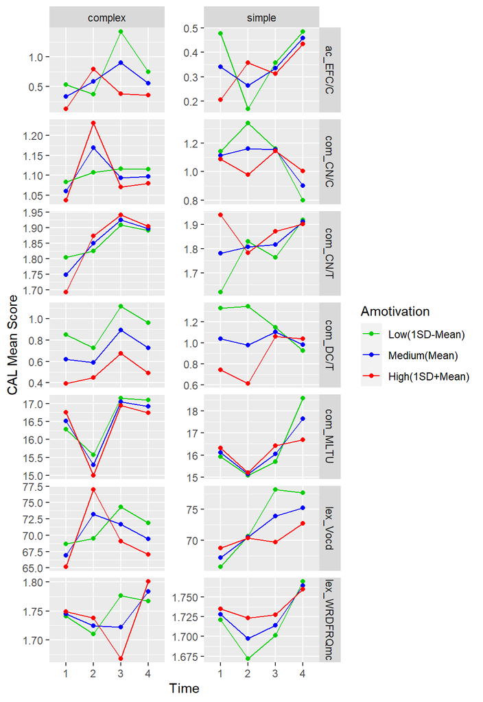

Figure 5. The impact of task repetition on CAL measures moderated by amotivation for simple and complex tasks

## 4.5 To what extent that impact moderated by the level of task intention for simple and complex tasks?

The impact of task repetition on CAL measures moderated by task intention for simple and complex tasks

inten

time

cal

task_dif

Mean

SE

Lower

Upper

t

p-value

Sig.

1.700

1

ac_EFC/C

complex

-0.060

0.503

-1.058

0.939

-0.118

0.906

2.900

1

ac_EFC/C

complex

0.235

0.277

-0.314

0.785

0.849

0.398

4.100

1

ac_EFC/C

complex

0.530

0.102

0.327

0.732

5.189

0.000

***

1.700

2

ac_EFC/C

complex

-0.453

0.424

-1.295

0.389

-1.069

0.288

2.900

2

ac_EFC/C

complex

-0.077

0.238

-0.549

0.396

-0.321

0.749

4.100

2

ac_EFC/C

complex

0.300

0.084

0.134

0.467

3.577

0.001

***

1.700

3

ac_EFC/C

complex

1.630

0.313

1.010

2.250

5.214

0.000

***

2.900

3

ac_EFC/C

complex

1.370

0.129

1.114

1.627

10.609

0.000

***

4.100

3

ac_EFC/C

complex

1.111

0.106

0.901

1.321

10.483

0.000

***

1.700

4

ac_EFC/C

complex

0.350

0.275

-0.196

0.896

1.271

0.207

2.900

4

ac_EFC/C

complex

0.563

0.115

0.336

0.791

4.910

0.000

***

4.100

4

ac_EFC/C

complex

0.777

0.099

0.580

0.974

7.820

0.000

***

1.700

1

com_CN/C

complex

1.195

0.212

0.774

1.617

5.626

0.000

***

2.900

1

com_CN/C

complex

1.143

0.117

0.911

1.375

9.781

0.000

***

4.100

1

com_CN/C

complex

1.091

0.043

1.005

1.176

25.359

0.000

***

1.700

2

com_CN/C

complex

1.002

0.178

0.649

1.356

5.631

0.000

***

2.900

2

com_CN/C

complex

1.049

0.100

0.851

1.247

10.510

0.000

***

4.100

2

com_CN/C

complex

1.096

0.035

1.026

1.166

31.208

0.000

***

1.700

3

com_CN/C

complex

1.203

0.130

0.944

1.461

9.229

0.000

***

2.900

3

com_CN/C

complex

1.142

0.054

1.035

1.249

21.228

0.000

***

4.100

3

com_CN/C

complex

1.081

0.044

0.994

1.169

24.518

0.000

***

1.700

4

com_CN/C

complex

1.065

0.115

0.837

1.292

9.292

0.000

***

2.900

4

com_CN/C

complex

1.093

0.048

0.998

1.188

22.918

0.000

***

4.100

4

com_CN/C

complex

1.121

0.041

1.039

1.203

27.168

0.000

***

1.700

1

com_CN/T

complex

1.858

0.109

1.641

2.074

17.028

0.000

***

2.900

1

com_CN/T

complex

1.836

0.060

1.717

1.955

30.588

0.000

***

4.100

1

com_CN/T

complex

1.813

0.022

1.770

1.857

82.127

0.000

***

1.700

2

com_CN/T

complex

1.776

0.091

1.595

1.957

19.478

0.000

***

2.900

2

com_CN/T

complex

1.799

0.051

1.697

1.900

35.170

0.000

***

4.100

2

com_CN/T

complex

1.821

0.018

1.785

1.857

101.254

0.000

***

1.700

3

com_CN/T

complex

1.952

0.067

1.820

2.084

29.316

0.000

***

2.900

3

com_CN/T

complex

1.929

0.027

1.875

1.984

70.198

0.000

***

4.100

3

com_CN/T

complex

1.906

0.023

1.862

1.951

84.621

0.000

***

1.700

4

com_CN/T

complex

1.841

0.059

1.725

1.957

31.475

0.000

***

2.900

4

com_CN/T

complex

1.875

0.024

1.827

1.923

77.025

0.000

***

4.100

4

com_CN/T

complex

1.909

0.021

1.867

1.951

90.625

0.000

***

1.700

1

com_DC/T

complex

0.362

0.609

-0.847

1.571

0.594

0.554

2.900

1

com_DC/T

complex

0.607

0.335

-0.058

1.272

1.811

0.073

.

4.100

1

com_DC/T

complex

0.852

0.123

0.607

1.097

6.909

0.000

***

1.700

2

com_DC/T

complex

-0.358

0.509

-1.368

0.653

-0.703

0.484

2.900

2

com_DC/T

complex

0.145

0.286

-0.422

0.711

0.506

0.614

4.100

2

com_DC/T

complex

0.647

0.100

0.448

0.846

6.441

0.000

***

1.700

3

com_DC/T

complex

1.087

0.372

0.349

1.825

2.923

0.004

2.900

3

com_DC/T

complex

1.049

0.153

0.744

1.354

6.834

0.000

***

4.100

3

com_DC/T

complex

1.011

0.126

0.761

1.261

8.034

0.000

***

1.700

4

com_DC/T

complex

1.101

0.327

0.452

1.749

3.368

0.001

2.900

4

com_DC/T

complex

0.957

0.136

0.688

1.227

7.042

0.000

***

4.100

4

com_DC/T

complex

0.814

0.118

0.581

1.048

6.921

0.000

***

1.700

1

com_MLTU

complex

15.973

1.291

13.410

18.535

12.368

0.000

***

2.900

1

com_MLTU

complex

16.106

0.710

14.696

17.515

22.674

0.000

***

4.100

1

com_MLTU

complex

16.239

0.261

15.720

16.758

62.134

0.000

***

1.700

2

com_MLTU

complex

14.634

1.079

12.492

16.776

13.557

0.000

***

2.900

2

com_MLTU

complex

15.072

0.605

13.871

16.274

24.901

0.000

***

4.100

2

com_MLTU

complex

15.511

0.213

15.089

15.933

72.868

0.000

***

1.700

3

com_MLTU

complex

18.514

0.788

16.950

20.078

23.490

0.000

***

2.900

3

com_MLTU

complex

17.619

0.325

16.973

18.264

54.161

0.000

***

4.100

3

com_MLTU

complex

16.724

0.267

16.195

17.253

62.715

0.000

***

1.700

4

com_MLTU

complex

17.046

0.692

15.672

18.420

24.618

0.000

***

2.900

4

com_MLTU

complex

17.034

0.288

16.463

17.606

59.115

0.000

***

4.100

4

com_MLTU

complex

17.023

0.249

16.528

17.517

68.271

0.000

***

1.700

1

lex_Vocd

complex

68.490

7.339

53.929

83.052

9.333

0.000

***

2.900

1

lex_Vocd

complex

68.667

4.036

60.658

76.675

17.012

0.000

***

4.100

1

lex_Vocd

complex

68.843

1.485

65.896

71.789

46.356

0.000

***

1.700

2

lex_Vocd

complex

59.861

6.134

47.690

72.031

9.760

0.000

***

2.900

2

lex_Vocd

complex

64.213

3.440

57.389

71.038

18.669

0.000

***

4.100

2

lex_Vocd

complex

68.566

1.210

66.166

70.966

56.687

0.000

***

1.700

3

lex_Vocd

complex

78.835

4.479

69.949

87.722

17.603

0.000

***

2.900

3

lex_Vocd

complex

75.296

1.848

71.628

78.964

40.734

0.000

***

4.100

3

lex_Vocd

complex

71.756

1.515

68.750

74.763

47.356

0.000

***

1.700

4

lex_Vocd

complex

68.215

3.935

60.408

76.022

17.337

0.000

***

2.900

4

lex_Vocd

complex

70.038

1.637

66.789

73.287

42.774

0.000

***

4.100

4

lex_Vocd

complex

71.860

1.417

69.049

74.671

50.719

0.000

***

1.700

1

lex_WRDFRQmc

complex

1.827

0.103

1.623

2.031

17.783

0.000

***

2.900

1

lex_WRDFRQmc

complex

1.786

0.057

1.674

1.898

31.600

0.000

***

4.100

1

lex_WRDFRQmc

complex

1.745

0.021

1.703

1.786

83.894

0.000

***

1.700

2

lex_WRDFRQmc

complex

1.758

0.086

1.587

1.928

20.466

0.000

***

2.900

2

lex_WRDFRQmc

complex

1.736

0.048

1.640

1.831

36.040

0.000

***

4.100

2

lex_WRDFRQmc

complex

1.714

0.017

1.680

1.747

101.188

0.000

***

1.700

3

lex_WRDFRQmc

complex

1.775

0.063

1.651

1.899

28.306

0.000

***

2.900

3

lex_WRDFRQmc

complex

1.762

0.026

1.711

1.814

68.093

0.000

***

4.100

3

lex_WRDFRQmc

complex

1.750

0.021

1.708

1.792

82.473

0.000

***

1.700

4

lex_WRDFRQmc

complex

1.727

0.055

1.618

1.836

31.348

0.000

***

2.900

4

lex_WRDFRQmc

complex

1.757

0.023

1.711

1.802

76.617

0.000

***

4.100

4

lex_WRDFRQmc

complex

1.786

0.020

1.747

1.825

90.033

0.000

***

1.700

1

ac_EFC/C

simple

0.249

0.126

0.000

0.498

1.987

0.050

2.900

1

ac_EFC/C

simple

0.274

0.141

-0.006

0.554

1.943

0.055

.

4.100

1

ac_EFC/C

simple

0.299

0.294

-0.285

0.883

1.016

0.312

1.700

2

ac_EFC/C

simple

0.307

0.116

0.077

0.538

2.642

0.010

2.900

2

ac_EFC/C

simple

0.350

0.094

0.164

0.535

3.738

0.000

***

4.100

2

ac_EFC/C

simple

0.392

0.208

-0.020

0.804

1.887

0.062

.

1.700

3

ac_EFC/C

simple

0.292

0.078

0.138

0.447

3.759

0.000

***

2.900

3

ac_EFC/C

simple

0.188

0.283

-0.374

0.751

0.663

0.509

4.100

3

ac_EFC/C

simple

0.084

0.514

-0.936

1.104

0.163

0.871

1.700

4

ac_EFC/C

simple

0.373

0.072

0.230

0.516

5.173

0.000

***

2.900

4

ac_EFC/C

simple

0.057

0.237

-0.413

0.526

0.239

0.812

4.100

4

ac_EFC/C

simple

-0.260

0.427

-1.106

0.587

-0.609

0.544

1.700

1

com_CN/C

simple

1.186

0.053

1.081

1.291

22.420

0.000

***

2.900

1

com_CN/C

simple

0.982

0.060

0.864

1.100

16.500

0.000

***

4.100

1

com_CN/C

simple

0.778

0.124

0.531

1.025

6.261

0.000

***

1.700

2

com_CN/C

simple

0.978

0.049

0.882

1.075

20.070

0.000

***

2.900

2

com_CN/C

simple

1.053

0.039

0.975

1.131

26.895

0.000

***

4.100

2

com_CN/C

simple

1.128

0.087

0.955

1.301

12.945

0.000

***

1.700

3

com_CN/C

simple

1.146

0.032

1.082

1.210

35.473

0.000

***

2.900

3

com_CN/C

simple

1.153

0.118

0.918

1.387

9.755

0.000

***

4.100

3

com_CN/C

simple

1.159

0.214

0.734

1.585

5.409

0.000

***

1.700

4

com_CN/C

simple

1.067

0.030

1.008

1.126

35.706

0.000

***

2.900

4

com_CN/C

simple

1.327

0.099

1.132

1.523

13.475

0.000

***

4.100

4

com_CN/C

simple

1.588

0.178

1.236

1.940

8.945

0.000

***

1.700

1

com_CN/T

simple

1.903

0.027

1.849

1.957

70.049

0.000

***

2.900

1

com_CN/T

simple

1.838

0.031

1.778

1.899

60.153

0.000

***

4.100

1

com_CN/T

simple

1.774

0.064

1.647

1.901

27.798

0.000

***

1.700

2

com_CN/T

simple

1.779

0.025

1.730

1.829

71.258

0.000

***

2.900

2

com_CN/T

simple

1.795

0.020

1.755

1.835

89.518

0.000

***

4.100

2

com_CN/T

simple

1.811

0.045

1.722

1.899

40.579

0.000

***

1.700

3

com_CN/T

simple

1.880

0.017

1.847

1.913

113.927

0.000

***

2.900

3

com_CN/T

simple

1.895

0.060

1.775

2.015

31.389

0.000

***

4.100

3

com_CN/T

simple

1.910

0.110

1.693

2.127

17.442

0.000

***

1.700

4

com_CN/T

simple

1.889

0.015

1.859

1.919

123.861

0.000

***

2.900

4

com_CN/T

simple

1.821

0.050

1.721

1.920

36.197

0.000

***

4.100

4

com_CN/T

simple

1.752

0.091

1.572

1.932

19.331

0.000

***

1.700

1

com_DC/T

simple

1.038

0.152

0.737

1.339

6.844

0.000

***

2.900

1

com_DC/T

simple

0.629

0.171

0.290

0.968

3.685

0.000

***

4.100

1

com_DC/T

simple

0.220

0.356

-0.488

0.927

0.616

0.539

1.700

2

com_DC/T

simple

0.514

0.139

0.237

0.791

3.687

0.000

***

2.900

2

com_DC/T

simple

0.814

0.112

0.592

1.036

7.270

0.000

***

4.100

2

com_DC/T

simple

1.114

0.249

0.620

1.609

4.471

0.000

***

1.700

3

com_DC/T

simple

1.119

0.092

0.936

1.302

12.141

0.000

***

2.900

3

com_DC/T

simple

1.481

0.337

0.812

2.150

4.393

0.000

***

4.100

3

com_DC/T

simple

1.844

0.612

0.630

3.057

3.015

0.003

1.700

4

com_DC/T

simple

0.992

0.085

0.823

1.161

11.649

0.000

***

2.900

4

com_DC/T

simple

0.684

0.281

0.127

1.241

2.435

0.017

4.100

4

com_DC/T

simple

0.376

0.506

-0.629

1.380

0.742

0.460

1.700

1

com_MLTU

simple

16.111

0.322

15.473

16.749

50.109

0.000

***

2.900

1

com_MLTU

simple

16.401

0.362

15.684

17.119

45.339

0.000

***

4.100

1

com_MLTU

simple

16.691

0.755

15.192

18.190

22.097

0.000

***

1.700

2

com_MLTU

simple

14.869

0.296

14.282

15.455

50.312

0.000

***

2.900

2

com_MLTU

simple

15.401

0.237

14.930

15.872

64.890

0.000

***

4.100

2

com_MLTU

simple

15.933

0.528

14.885

16.981

30.165

0.000

***

1.700

3

com_MLTU

simple

16.465

0.195

16.078

16.853

84.304

0.000

***

2.900

3

com_MLTU

simple

16.496

0.715

15.078

17.914

23.086

0.000

***

4.100

3

com_MLTU

simple

16.527

1.296

13.955

19.099

12.750

0.000

***

1.700

4

com_MLTU

simple

16.579

0.181

16.221

16.937

91.848

0.000

***

2.900

4

com_MLTU

simple

16.707

0.595

15.526

17.889

28.065

0.000

***

4.100

4

com_MLTU

simple

16.836

1.073

14.707

18.965

15.693

0.000

***

1.700

1

lex_Vocd

simple

66.645

1.827

63.019

70.270

36.478

0.000

***

2.900

1

lex_Vocd

simple

70.054

2.056

65.975

74.133

34.080

0.000

***

4.100

1

lex_Vocd

simple

73.463

4.292

64.947

81.980

17.115

0.000

***

1.700

2

lex_Vocd

simple

71.832

1.679

68.500

75.164

42.776

0.000

***

2.900

2

lex_Vocd

simple

69.514

1.349

66.838

72.190

51.544

0.000

***

4.100

2

lex_Vocd

simple

67.197

3.001

61.241

73.152

22.388

0.000

***

1.700

3

lex_Vocd

simple

69.528

1.110

67.326

71.730

62.648

0.000

***

2.900

3

lex_Vocd

simple

70.817

4.060

62.760

78.873

17.441

0.000

***

4.100

3

lex_Vocd

simple

72.106

7.365

57.491

86.720

9.790

0.000

***

1.700

4

lex_Vocd

simple

72.727

1.026

70.691

74.762

70.907

0.000

***

2.900

4

lex_Vocd

simple

74.933

3.383

68.221

81.645

22.152

0.000

***

4.100

4

lex_Vocd

simple

77.139

6.096

65.043

89.236

12.654

0.000

***

1.700

1

lex_WRDFRQmc

simple

1.726

0.026

1.675

1.777

67.480

0.000

***

2.900

1

lex_WRDFRQmc

simple

1.740

0.029

1.682

1.797

60.437

0.000

***

4.100

1

lex_WRDFRQmc

simple

1.753

0.060

1.634

1.872

29.164

0.000

***

1.700

2

lex_WRDFRQmc

simple

1.705

0.024

1.659

1.752

72.534

0.000

***

2.900

2

lex_WRDFRQmc

simple

1.724

0.019

1.686

1.761

91.278

0.000

***

4.100

2

lex_WRDFRQmc

simple

1.742

0.042

1.658

1.825

41.447

0.000

***

1.700

3

lex_WRDFRQmc

simple

1.711

0.016

1.680

1.742

110.096

0.000

***

2.900

3

lex_WRDFRQmc

simple

1.610

0.057

1.497

1.723

28.317

0.000

***

4.100

3

lex_WRDFRQmc

simple

1.509

0.103

1.304

1.714

14.632

0.000

***

1.700

4

lex_WRDFRQmc

simple

1.756

0.014

1.727

1.784

122.240

0.000

***

2.900

4

lex_WRDFRQmc

simple

1.737

0.047

1.643

1.831

36.677

0.000

***

4.100

4

lex_WRDFRQmc

simple

1.719

0.085

1.550

1.888

20.137

0.000

***

Quantification of the model characteristics

| Terms | τ (SD) | ρ | σ (SD) |
| --- | --- | --- | --- |
| **Random-Effects’ Variation Across CALs** |  |  |  |
| ac_EFC/C | 0.120689 |  |  |
| com_CN/C | 0.026032 |  |  |
| com_CN/T | 0.000001 |  |  |
| com_DC/T | 0.000003 |  |  |
| com_MLTU | 0.000004 |  |  |
| lex_Vocd | 0.000568 |  |  |
| lex_WRDFRQmc | 0.000059 |  |  |
| **Residuals’ Common Corr. Across Participants** |  |  |  |
| Corr. Estimate |  | 0.005 |  |
| **Residuals’ Variation Across Times and CALs** |  |  |  |
| Time 1 |  |  | 1.798 |
| Time 2 |  |  | 1.577 |
| Time 3 |  |  | 1.447 |
| Time 4 |  |  | 1.419 |
| com_MLTU |  |  | 1.798 |
| com_DC/T |  |  | 1.235 |
| com_CN/T |  |  | 0.523 |
| com_CN/C |  |  | 0.728 |
| ac_EFC/C |  |  | 1.116 |
| lex_Vocd |  |  | 4.286 |
| lex_WRDFRQmc |  |  | 0.507 |

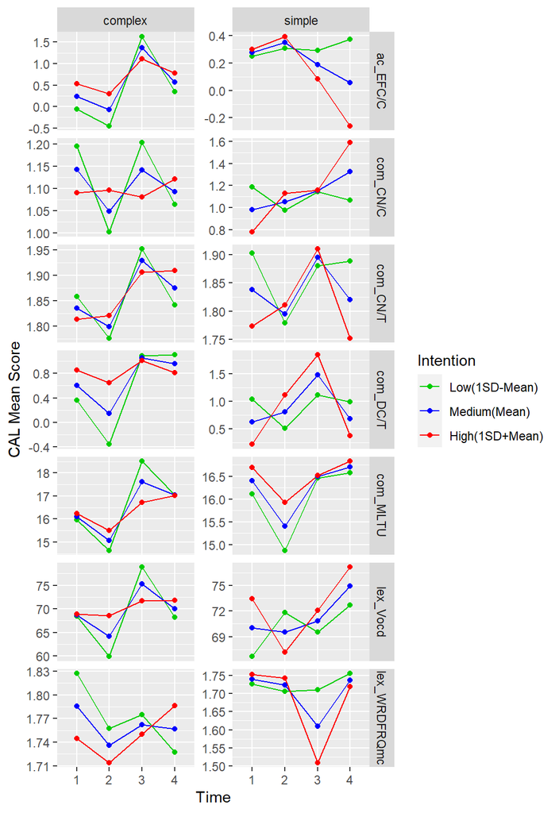

Figure 6. The impact of task repetition on CAL measures moderated by task intention for simple and complex tasks

# 5 RQ2c

## 5.1 To what extent is that impact moderated by the degree of time on task for simple and complex tasks?

The impact of task repetition on CAL measures moderated by time on task for simple and complex tasks for simple and complex tasks

time_on_task

time

cal

task_dif

Mean

SE

Lower

Upper

t

p-value

Sig.

28.000

1

ac_EFC/C

complex

0.155

0.203

-0.247

0.557

0.763

0.447

32.600

1

ac_EFC/C

complex

0.402

0.121

0.161

0.642

3.315

0.001

37.200

1

ac_EFC/C

complex

0.648

0.107

0.436

0.861

6.059

0.000

***

28.000

2

ac_EFC/C

complex

0.475

0.187

0.104

0.845

2.543

0.013

32.600

2

ac_EFC/C

complex

0.410

0.105

0.203

0.618

3.918

0.000

***

37.200

2

ac_EFC/C

complex

0.346

0.083

0.181

0.512

4.160

0.000

***

28.000

3

ac_EFC/C

complex

1.176

0.150

0.879

1.473

7.856

0.000

***

32.600

3

ac_EFC/C

complex

1.205

0.082

1.041

1.369

14.612

0.000

***

37.200

3

ac_EFC/C

complex

1.234

0.075

1.085

1.384

16.392

0.000

***

28.000

4

ac_EFC/C

complex

0.611

0.149

0.315

0.906

4.099

0.000

***

32.600

4

ac_EFC/C

complex

0.662

0.074

0.515

0.809

8.914

0.000

***

37.200

4

ac_EFC/C

complex

0.713

0.087

0.541

0.886

8.209

0.000

***

28.000

1

com_CN/C

complex

1.122

0.086

0.950

1.293

12.974

0.000

***

32.600

1

com_CN/C

complex

1.100

0.052

0.997

1.202

21.302

0.000

***

37.200

1

com_CN/C

complex

1.077

0.046

0.987

1.168

23.642

0.000

***

28.000

2

com_CN/C

complex

1.130

0.079

0.973

1.286

14.326

0.000

***

32.600

2

com_CN/C

complex

1.115

0.044

1.027

1.202

25.212

0.000

***

37.200

2

com_CN/C

complex

1.100

0.035

1.030

1.169

31.340

0.000

***

28.000

3

com_CN/C

complex

1.117

0.063

0.993

1.241

17.832

0.000

***

32.600

3

com_CN/C

complex

1.111

0.034

1.043

1.179

32.263

0.000

***

37.200

3

com_CN/C

complex

1.105

0.031

1.042

1.167

35.167

0.000

***

28.000

4

com_CN/C

complex

1.092

0.062

0.968

1.215

17.553

0.000

***

32.600

4

com_CN/C

complex

1.104

0.031

1.043

1.165

35.717

0.000

***

37.200

4

com_CN/C

complex

1.116

0.036

1.044

1.188

30.824

0.000

***

28.000

1

com_CN/T

complex

1.799

0.044

1.713

1.886

41.239

0.000

***

32.600

1

com_CN/T

complex

1.807

0.026

1.755

1.858

69.348

0.000

***

37.200

1

com_CN/T

complex

1.814

0.023

1.768

1.859

78.859

0.000

***

28.000

2

com_CN/T

complex

1.793

0.040

1.714

1.872

45.033

0.000

***

32.600

2

com_CN/T

complex

1.812

0.022

1.767

1.856

81.177

0.000

***

37.200

2

com_CN/T

complex

1.830

0.018

1.795

1.866

103.359

0.000

***

28.000

3

com_CN/T

complex

1.896

0.032

1.834

1.959

59.986

0.000

***

32.600

3

com_CN/T

complex

1.909

0.017

1.874

1.943

109.854

0.000

***

37.200

3

com_CN/T

complex

1.921

0.016

1.890

1.953

121.199

0.000

***

28.000

4

com_CN/T

complex

1.908

0.031

1.846

1.970

60.767

0.000

***

32.600

4

com_CN/T

complex

1.898

0.016

1.867

1.929

121.665

0.000

***

37.200

4

com_CN/T

complex

1.888

0.018

1.852

1.924

103.325

0.000

***

28.000

1

com_DC/T

complex

0.796

0.246

0.308

1.284

3.235

0.002

32.600

1

com_DC/T

complex

0.845

0.147

0.554

1.136

5.755

0.000

***

37.200

1

com_DC/T

complex

0.894

0.130

0.637

1.152

6.899

0.000

***

28.000

2

com_DC/T

complex

0.863

0.224

0.418

1.308

3.847

0.000

***

32.600

2

com_DC/T

complex

0.787

0.126

0.537

1.037

6.258

0.000

***

37.200

2

com_DC/T

complex

0.711

0.100

0.513

0.909

7.123

0.000

***

28.000

3

com_DC/T

complex

1.363

0.178

1.010

1.717

7.651

0.000

***

32.600

3

com_DC/T

complex

1.150

0.098

0.956

1.345

11.745

0.000

***

37.200

3

com_DC/T

complex

0.937

0.089

0.760

1.115

10.490

0.000

***

28.000

4

com_DC/T

complex

0.875

0.177

0.524

1.226

4.943

0.000

***

32.600

4

com_DC/T

complex

0.877

0.088

0.703

1.051

9.975

0.000

***

37.200

4

com_DC/T

complex

0.879

0.103

0.675

1.084

8.538

0.000

***

28.000

1

com_MLTU

complex

16.579

0.514

15.559

17.598

32.258

0.000

***

32.600

1

com_MLTU

complex

16.380

0.307

15.771

16.988

53.382

0.000

***

37.200

1

com_MLTU

complex

16.181

0.271

15.643

16.718

59.729

0.000

***

28.000

2

com_MLTU

complex

15.492

0.469

14.561

16.422

33.042

0.000

***

32.600

2

com_MLTU

complex

15.547

0.263

15.026

16.069

59.153

0.000

***

37.200

2

com_MLTU

complex

15.603

0.209

15.189

16.017

74.807

0.000

***

28.000

3

com_MLTU

complex

17.376

0.372

16.637

18.115

46.664

0.000

***

32.600

3

com_MLTU

complex

17.205

0.205

16.799

17.611

84.063

0.000

***

37.200

3

com_MLTU

complex

17.035

0.187

16.664

17.405

91.227

0.000

***

28.000

4

com_MLTU

complex

16.803

0.370

16.069

17.536

45.440

0.000

***

32.600

4

com_MLTU

complex

16.964

0.184

16.600

17.329

92.334

0.000

***

37.200

4

com_MLTU

complex

17.126

0.215

16.699

17.553

79.580

0.000

***

28.000

1

lex_Vocd

complex

65.459

2.936

59.633

71.286

22.292

0.000

***

32.600

1

lex_Vocd

complex

67.534

1.753

64.055

71.013

38.522

0.000

***

37.200

1

lex_Vocd

complex

69.609

1.548

66.538

72.680

44.973

0.000

***

28.000

2

lex_Vocd

complex

68.059

2.679

62.744

73.375

25.407

0.000

***

32.600

2

lex_Vocd

complex

68.797

1.502

65.817

71.776

45.812

0.000

***

37.200

2

lex_Vocd

complex

69.534

1.192

67.169

71.899

58.348

0.000

***

28.000

3

lex_Vocd

complex

73.519

2.128

69.297

77.740

34.556

0.000

***

32.600

3

lex_Vocd

complex

73.361

1.169

71.041

75.682

62.734

0.000

***

37.200

3

lex_Vocd

complex

73.204

1.067

71.087

75.321

68.615

0.000

***

28.000

4

lex_Vocd

complex

70.982

2.113

66.790

75.174

33.597

0.000

***

32.600

4

lex_Vocd

complex

71.031

1.050

68.948

73.114

67.665

0.000

***

37.200

4

lex_Vocd

complex

71.080

1.230

68.640

73.520

57.807

0.000

***

28.000

1

lex_WRDFRQmc

complex

1.740

0.041

1.658

1.822

42.099

0.000

***

32.600

1

lex_WRDFRQmc

complex

1.740

0.025

1.691

1.789

70.534

0.000

***

37.200

1

lex_WRDFRQmc

complex

1.741

0.022

1.697

1.784

79.912

0.000

***

28.000

2

lex_WRDFRQmc

complex

1.720

0.038

1.645

1.795

45.636

0.000

***

32.600

2

lex_WRDFRQmc

complex

1.714

0.021

1.672

1.756

81.120

0.000

***

37.200

2

lex_WRDFRQmc

complex

1.708

0.017

1.675

1.741

101.861

0.000

***

28.000

3

lex_WRDFRQmc

complex

1.760

0.030

1.701

1.820

58.793

0.000

***

32.600

3

lex_WRDFRQmc

complex

1.757

0.016

1.724

1.790

106.772

0.000

***

37.200

3

lex_WRDFRQmc

complex

1.754

0.015

1.724

1.784

116.820

0.000

***

28.000

4

lex_WRDFRQmc

complex

1.749

0.030

1.690

1.808

58.833

0.000

***

32.600

4

lex_WRDFRQmc

complex

1.766

0.015

1.737

1.796

119.568

0.000

***

37.200

4

lex_WRDFRQmc

complex

1.783

0.017

1.749

1.818

103.069

0.000

***

28.000

1

ac_EFC/C

simple

0.254

0.129

-0.002

0.509

1.970

0.052

.

32.600

1

ac_EFC/C

simple

0.265

0.118

0.030

0.500

2.242

0.027

37.200

1

ac_EFC/C

simple

0.277

0.232

-0.182

0.736

1.197

0.234

28.000

2

ac_EFC/C

simple

0.337

0.122

0.095

0.579

2.764

0.007

32.600

2

ac_EFC/C

simple

0.333

0.079

0.176

0.491

4.194

0.000

***

37.200

2

ac_EFC/C

simple

0.330

0.147

0.037

0.622

2.237

0.028

28.000

3

ac_EFC/C

simple

0.316

0.068

0.181

0.452

4.649

0.000

***

32.600

3

ac_EFC/C

simple

0.351

0.130

0.092

0.610

2.693

0.008

37.200

3

ac_EFC/C

simple

0.386

0.219

-0.049

0.820

1.762

0.081

.

28.000

4

ac_EFC/C

simple

0.422

0.070

0.284

0.560

6.055

0.000

***

32.600

4

ac_EFC/C

simple

0.441

0.080

0.283

0.599

5.533

0.000

***

37.200

4

ac_EFC/C

simple

0.459

0.139

0.184

0.734

3.313

0.001

28.000

1

com_CN/C

simple

1.099

0.055

0.990

1.207

20.024

0.000

***

32.600

1

com_CN/C

simple

1.097

0.050

0.997

1.197

21.757

0.000

***

37.200

1

com_CN/C

simple

1.096

0.099

0.900

1.292

11.092

0.000

***

28.000

2

com_CN/C

simple

1.136

0.051

1.034

1.238

22.069

0.000

***

32.600

2

com_CN/C

simple

1.006

0.033

0.940

1.073

30.062

0.000

***

37.200

2

com_CN/C

simple

0.877

0.062

0.753

1.000

14.074

0.000

***

28.000

3

com_CN/C

simple

1.148

0.028

1.092

1.204

40.449

0.000

***

32.600

3

com_CN/C

simple

1.166

0.055

1.058

1.275

21.380

0.000

***

37.200

3

com_CN/C

simple

1.185

0.092

1.003

1.367

12.920

0.000

***

28.000

4

com_CN/C

simple

1.027

0.029

0.970

1.085

35.434

0.000

***

32.600

4

com_CN/C

simple

1.009

0.033

0.943

1.075

30.430

0.000

***

37.200

4

com_CN/C

simple

0.991

0.058

0.876

1.106

17.132

0.000

***

28.000

1

com_CN/T

simple

1.915

0.028

1.860

1.970

69.147

0.000

***

32.600

1

com_CN/T

simple

1.844

0.025

1.793

1.894

72.452

0.000

***

37.200

1

com_CN/T

simple

1.773

0.050

1.674

1.872

35.565

0.000

***

28.000

2

com_CN/T

simple

1.789

0.026

1.738

1.841

68.882

0.000

***

32.600

2

com_CN/T

simple

1.789

0.017

1.755

1.822

105.889

0.000

***

37.200

2

com_CN/T

simple

1.788

0.031

1.726

1.851

56.887

0.000

***

28.000

3

com_CN/T

simple

1.879

0.014

1.851

1.908

131.194

0.000

***

32.600

3

com_CN/T

simple

1.891

0.028

1.836

1.945

68.671

0.000

***

37.200

3

com_CN/T

simple

1.902

0.046

1.811

1.994

41.103

0.000

***

28.000

4

com_CN/T

simple

1.894

0.015

1.865

1.923

129.455

0.000

***

32.600

4

com_CN/T

simple

1.912

0.017

1.879

1.946

114.257

0.000

***

37.200

4

com_CN/T

simple

1.930

0.029

1.872

1.988

66.126

0.000

***

28.000

1

com_DC/T

simple

0.976

0.156

0.666

1.286

6.255

0.000

***

32.600

1

com_DC/T

simple

0.771

0.143

0.486

1.055

5.373

0.000

***

37.200

1

com_DC/T

simple

0.565

0.281

0.008

1.123

2.012

0.047

28.000

2

com_DC/T

simple

0.722

0.146

0.432

1.013

4.934

0.000

***

32.600

2

com_DC/T

simple

0.697

0.095

0.508

0.886

7.322

0.000

***

37.200

2

com_DC/T

simple

0.672

0.177

0.320

1.024

3.792

0.000

***

28.000

3

com_DC/T

simple

1.055

0.081

0.895

1.216

13.075

0.000

***

32.600

3

com_DC/T

simple

1.062

0.155

0.754

1.370

6.843

0.000

***

37.200

3

com_DC/T

simple

1.069

0.261

0.551

1.586

4.096

0.000

***

28.000

4

com_DC/T

simple

0.999

0.082

0.835

1.162

12.107

0.000

***

32.600

4

com_DC/T

simple

1.129

0.094

0.942

1.316

11.971

0.000

***

37.200

4

com_DC/T

simple

1.260

0.165

0.934

1.587

7.658

0.000

***

28.000

1

com_MLTU

simple

16.499

0.326

15.852

17.146

50.589

0.000

***

32.600

1

com_MLTU

simple

16.032

0.300

15.437

16.627

53.488

0.000

***

37.200

1

com_MLTU

simple

15.566

0.587

14.401

16.731

26.511

0.000

***

28.000

2

com_MLTU

simple

15.229

0.306

14.622

15.837

49.773

0.000

***

32.600

2

com_MLTU

simple

15.195

0.199

14.800

15.590

76.363

0.000

***

37.200

2

com_MLTU

simple

15.160

0.370

14.426

15.895

40.943

0.000

***

28.000

3

com_MLTU

simple

16.433

0.169

16.098

16.768

97.410

0.000

***

32.600

3

com_MLTU

simple

16.270

0.324

15.627

16.914

50.171

0.000

***

37.200

3

com_MLTU

simple

16.107

0.545

15.026

17.189

29.547

0.000

***

28.000

4

com_MLTU

simple

16.381

0.172

16.039

16.723

95.044

0.000

***

32.600

4

com_MLTU

simple

16.854

0.197

16.463

17.245

85.495

0.000

***

37.200

4

com_MLTU

simple

17.327

0.344

16.645

18.009

50.394

0.000

***

28.000

1

lex_Vocd

simple

69.213

1.863

65.516

72.910

37.144

0.000

***

32.600

1

lex_Vocd

simple

67.268

1.713

63.870

70.666

39.280

0.000

***

37.200

1

lex_Vocd

simple

65.323

3.355

58.667

71.979

19.472

0.000

***

28.000

2

lex_Vocd

simple

72.357

1.748

68.888

75.826

41.390

0.000

***

32.600

2

lex_Vocd

simple

70.060

1.137

67.804

72.316

61.624

0.000

***

37.200

2

lex_Vocd

simple

67.763

2.116

63.565

71.960

32.030

0.000

***

28.000

3

lex_Vocd

simple

69.233

0.964

67.321

71.146

71.828

0.000

***

32.600

3

lex_Vocd

simple

68.839

1.853

65.163

72.516

37.153

0.000

***

37.200

3

lex_Vocd

simple

68.445

3.115

62.265

74.626

21.975

0.000

***

28.000

4

lex_Vocd

simple

71.714

0.985

69.760

73.668

72.825

0.000

***

32.600

4

lex_Vocd

simple

73.393

1.126

71.158

75.628

65.161

0.000

***

37.200

4

lex_Vocd

simple

75.073

1.964

71.175

78.971

38.215

0.000

***

28.000

1

lex_WRDFRQmc

simple

1.748

0.026

1.696

1.800

66.663

0.000

***

32.600

1

lex_WRDFRQmc

simple

1.719

0.024

1.672

1.767

71.350

0.000

***

37.200

1

lex_WRDFRQmc

simple

1.691

0.047

1.597

1.785

35.820

0.000

***

28.000

2

lex_WRDFRQmc

simple

1.714

0.025

1.666

1.763

69.692

0.000

***

32.600

2

lex_WRDFRQmc

simple

1.717

0.016

1.685

1.749

107.333

0.000

***

37.200

2

lex_WRDFRQmc

simple

1.720

0.030

1.661

1.779

57.770

0.000

***

28.000

3

lex_WRDFRQmc

simple

1.730

0.014

1.703

1.757

127.549

0.000

***

32.600

3

lex_WRDFRQmc

simple

1.738

0.026

1.686

1.789

66.645

0.000

***

37.200

3

lex_WRDFRQmc

simple

1.745

0.044

1.658

1.832

39.820

0.000

***

28.000

4

lex_WRDFRQmc

simple

1.755

0.014

1.728

1.783

126.656

0.000

***

32.600

4

lex_WRDFRQmc

simple

1.765

0.016

1.734

1.797

111.360

0.000

***

37.200

4

lex_WRDFRQmc

simple

1.775

0.028

1.720

1.830

64.207

0.000

***

Quantification of the model characteristics

| Terms | τ (SD) | ρ | σ (SD) |
| --- | --- | --- | --- |
| **Random-Effects’ Variation Across CALs** |  |  |  |
| ac_EFC/C | 0.125765 |  |  |
| com_CN/C | 0.000039 |  |  |
| com_CN/T | 0.000003 |  |  |
| com_DC/T | 0.000005 |  |  |
| com_MLTU | 0.000002 |  |  |
| lex_Vocd | 0.001493 |  |  |
| lex_WRDFRQmc | 0.000020 |  |  |
| **Residuals’ Common Corr. Across Participants** |  |  |  |
| Corr. Estimate |  | 0.006 |  |
| **Residuals’ Variation Across Times and CALs** |  |  |  |
| Time 1 |  |  | 1.784 |
| Time 2 |  |  | 1.569 |
| Time 3 |  |  | 1.438 |
| Time 4 |  |  | 1.411 |
| com_MLTU |  |  | 1.784 |
| com_DC/T |  |  | 1.234 |
| com_CN/T |  |  | 0.520 |
| com_CN/C |  |  | 0.732 |
| ac_EFC/C |  |  | 1.113 |
| lex_Vocd |  |  | 4.265 |
| lex_WRDFRQmc |  |  | 0.506 |

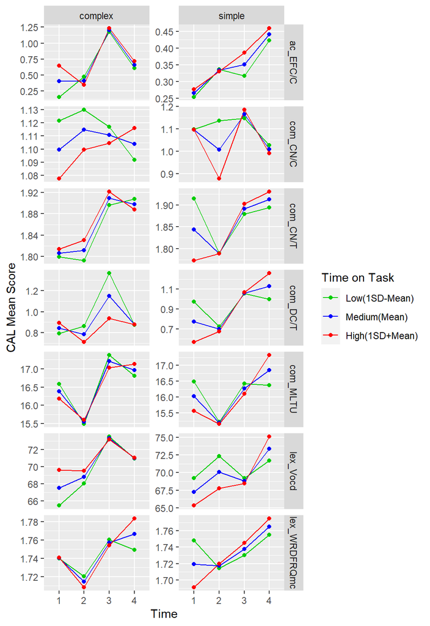

Figure 7. The impact of task repetition on CAL measures moderated by time on task for simple and complex tasks

## 5.2 To what extent is that impact moderated by the length of writing for simple and complex tasks?

The impact of task repetition on CAL measures moderated by writing length for simple and complex tasks

length_writing

time

cal

task_dif

Mean

SE

Lower

Upper

t

p-value

Sig.

337.300

1

ac_EFC/C

complex

0.481

0.122

0.239

0.722

3.951

0.000

***

385.100

1

ac_EFC/C

complex

0.625

0.116

0.395

0.855

5.400

0.000

***

433.000

1

ac_EFC/C

complex

0.769

0.208

0.356

1.182

3.696

0.000

***

337.300

2

ac_EFC/C

complex

0.413

0.094

0.227

0.600

4.396

0.000

***

385.100

2

ac_EFC/C

complex

0.325

0.090

0.147

0.503

3.627

0.000

***

433.000

2

ac_EFC/C

complex

0.237

0.163

-0.086

0.559

1.455

0.149

337.300

3

ac_EFC/C

complex

1.157

0.105

0.949

1.364

11.055

0.000

***

385.100

3

ac_EFC/C

complex

1.206

0.069

1.070

1.343

17.530

0.000

***

433.000

3

ac_EFC/C

complex

1.256

0.078

1.100

1.411

16.011

0.000

***

337.300

4

ac_EFC/C

complex

0.585

0.113

0.361

0.810

5.168

0.000

***

385.100

4

ac_EFC/C

complex

0.670

0.065

0.541

0.799

10.324

0.000

***

433.000

4

ac_EFC/C

complex

0.755

0.095

0.567

0.943

7.963

0.000

***

337.300

1

com_CN/C

complex

1.091

0.051

0.989

1.193

21.232

0.000

***

385.100

1

com_CN/C

complex

1.081

0.049

0.984

1.178

22.127

0.000

***

433.000

1

com_CN/C

complex

1.071

0.088

0.897

1.246

12.181

0.000

***

337.300

2

com_CN/C

complex

1.103

0.039

1.025

1.181

28.007

0.000

***

385.100

2

com_CN/C

complex

1.105

0.038

1.030

1.179

29.434

0.000

***

433.000

2

com_CN/C

complex

1.107

0.068

0.971

1.242

16.223

0.000

***

337.300

3

com_CN/C

complex

1.127

0.044

1.041

1.214

25.867

0.000

***

385.100

3

com_CN/C

complex

1.112

0.029

1.055

1.169

38.860

0.000

***

433.000

3

com_CN/C

complex

1.097

0.033

1.032

1.162

33.599

0.000

***

337.300

4

com_CN/C

complex

1.115

0.047

1.022

1.209

23.680

0.000

***

385.100

4

com_CN/C

complex

1.109

0.027

1.056

1.163

41.194

0.000

***

433.000

4

com_CN/C

complex

1.104

0.039

1.025

1.182

28.015

0.000

***

337.300

1

com_CN/T

complex

1.802

0.026

1.751

1.854

69.718

0.000

***

385.100

1

com_CN/T

complex

1.818

0.025

1.770

1.867

73.964

0.000

***

433.000

1

com_CN/T

complex

1.835

0.044

1.747

1.922

41.449

0.000

***

337.300

2

com_CN/T

complex

1.802

0.020

1.763

1.842

90.916

0.000

***

385.100

2

com_CN/T

complex

1.844

0.019

1.806

1.881

97.603

0.000

***

433.000

2

com_CN/T

complex

1.885

0.034

1.817

1.953

54.924

0.000

***

337.300

3

com_CN/T

complex

1.911

0.022

1.868

1.955

87.126

0.000

***

385.100

3

com_CN/T

complex

1.915

0.014

1.886

1.944

132.966

0.000

***

433.000

3

com_CN/T

complex

1.919

0.016

1.886

1.951

116.813

0.000

***

337.300

4

com_CN/T

complex

1.906

0.024

1.859

1.953

80.416

0.000

***

385.100

4

com_CN/T

complex

1.896

0.014

1.869

1.922

139.854

0.000

***

433.000

4

com_CN/T

complex

1.885

0.020

1.846

1.924

95.081

0.000

***

337.300

1

com_DC/T

complex

0.924

0.147

0.633

1.215

6.303

0.000

***

385.100

1

com_DC/T

complex

0.837

0.139

0.560

1.114

6.004

0.000

***

433.000

1

com_DC/T

complex

0.750

0.251

0.252

1.248

2.988

0.004

337.300

2

com_DC/T

complex

0.790

0.112

0.567

1.013

7.030

0.000

***

385.100

2

com_DC/T

complex

0.686

0.107

0.473

0.898

6.401

0.000

***

433.000

2

com_DC/T

complex

0.581

0.195

0.195

0.967

2.984

0.004

337.300

3

com_DC/T

complex

0.946

0.124

0.699

1.193

7.606

0.000

***

385.100

3

com_DC/T

complex

1.008

0.082

0.846

1.170

12.341

0.000

***

433.000

3

com_DC/T

complex

1.070

0.093

0.885

1.254

11.484

0.000

***

337.300

4

com_DC/T

complex

0.764

0.134

0.497

1.031

5.686

0.000

***

385.100

4

com_DC/T

complex

0.863

0.077

0.711

1.016

11.237

0.000

***

433.000

4

com_DC/T

complex

0.963

0.112

0.740

1.186

8.569

0.000

***

337.300

1

com_MLTU

complex

16.205

0.309

15.591

16.818

52.405

0.000

***

385.100

1

com_MLTU

complex

16.292

0.294

15.709

16.876

55.402

0.000

***

433.000

1

com_MLTU

complex

16.380

0.529

15.329

17.430

30.940

0.000

***

337.300

2

com_MLTU

complex

15.587

0.237

15.116

16.057

65.737

0.000

***

385.100

2

com_MLTU

complex

15.587

0.226

15.138

16.035

68.985

0.000

***

433.000

2

com_MLTU

complex

15.587

0.411

14.772

16.401

37.964

0.000

***

337.300

3

com_MLTU

complex

17.380

0.262

16.859

17.900

66.245

0.000

***

385.100

3

com_MLTU

complex

17.172

0.172

16.830

17.514

99.689

0.000

***

433.000

3

com_MLTU

complex

16.964

0.196

16.574

17.354

86.342

0.000

***

337.300

4

com_MLTU

complex

16.797

0.283

16.235

17.360

59.251

0.000

***

385.100

4

com_MLTU

complex

16.999

0.162

16.677

17.320

104.860

0.000

***

433.000

4

com_MLTU

complex

17.201

0.237

16.730

17.671

72.539

0.000

***

337.300

1

lex_Vocd

complex

68.253

1.762

64.757

71.748

38.739

0.000

***

385.100

1

lex_Vocd

complex

69.367

1.676

66.043

72.692

41.400

0.000

***

433.000

1

lex_Vocd

complex

70.484

3.016

64.499

76.469

23.368

0.000

***

337.300

2

lex_Vocd

complex

69.726

1.351

67.045

72.406

51.612

0.000

***

385.100

2

lex_Vocd

complex

68.970

1.287

66.416

71.525

53.575

0.000

***

433.000

2

lex_Vocd

complex

68.214

2.339

63.572

72.855

29.160

0.000

***

337.300

3

lex_Vocd

complex

72.842

1.495

69.876

75.808

48.729

0.000

***

385.100

3

lex_Vocd

complex

73.168

0.981

71.220

75.115

74.549

0.000

***

433.000

3

lex_Vocd

complex

73.494

1.119

71.273

75.715

65.652

0.000

***

337.300

4

lex_Vocd

complex

70.663

1.615

67.458

73.868

43.748

0.000

***

385.100

4

lex_Vocd

complex

71.001

0.924

69.169

72.834

76.870

0.000

***

433.000

4

lex_Vocd

complex

71.340

1.351

68.659

74.021

52.803

0.000

***

337.300

1

lex_WRDFRQmc

complex

1.754

0.024

1.706

1.803

71.785

0.000

***

385.100

1

lex_WRDFRQmc

complex

1.729

0.023

1.683

1.775

74.384

0.000

***

433.000

1

lex_WRDFRQmc

complex

1.703

0.042

1.620

1.786

40.706

0.000

***

337.300

2

lex_WRDFRQmc

complex

1.717

0.019

1.680

1.754

91.617

0.000

***

385.100

2

lex_WRDFRQmc

complex

1.704

0.018

1.669

1.740

95.437

0.000

***

433.000

2

lex_WRDFRQmc

complex

1.692

0.032

1.627

1.756

52.132

0.000

***

337.300

3

lex_WRDFRQmc

complex

1.776

0.021

1.735

1.817

85.664

0.000

***

385.100

3

lex_WRDFRQmc

complex

1.760

0.014

1.733

1.787

129.296

0.000

***

433.000

3

lex_WRDFRQmc

complex

1.744

0.016

1.713

1.775

112.327

0.000

***

337.300

4

lex_WRDFRQmc

complex

1.749

0.022

1.704

1.793

78.048

0.000

***

385.100

4

lex_WRDFRQmc

complex

1.770

0.013

1.744

1.795

138.146

0.000

***

433.000

4

lex_WRDFRQmc

complex

1.791

0.019

1.754

1.828

95.580

0.000

***

337.300

1

ac_EFC/C

simple

0.268

0.141

-0.010

0.547

1.910

0.059

.

385.100

1

ac_EFC/C

simple

0.260

0.101

0.060

0.460

2.581

0.011

433.000

1

ac_EFC/C

simple

0.252

0.140

-0.025

0.529

1.805

0.074

.

337.300

2

ac_EFC/C

simple

0.309

0.094

0.122

0.496

3.278

0.001

385.100

2

ac_EFC/C

simple

0.351

0.086

0.181

0.522

4.084

0.000

***

433.000

2

ac_EFC/C

simple

0.393

0.149

0.097

0.690

2.633

0.010

337.300

3

ac_EFC/C

simple

0.347

0.129

0.092

0.602

2.702

0.008

385.100

3

ac_EFC/C

simple

0.327

0.081

0.165

0.488

4.009

0.000

***

433.000

3

ac_EFC/C

simple

0.306

0.068

0.172

0.440

4.521

0.000

***

337.300

4

ac_EFC/C

simple

0.508

0.101

0.308

0.708

5.034

0.000

***

385.100

4

ac_EFC/C

simple

0.436

0.064

0.309

0.563

6.794

0.000

***

433.000

4

ac_EFC/C

simple

0.364

0.091

0.184

0.544

4.017

0.000

***

337.300

1

com_CN/C

simple

1.126

0.059

1.008

1.244

18.975

0.000

***

385.100

1

com_CN/C

simple

1.098

0.043

1.014

1.182

25.812

0.000

***

433.000

1

com_CN/C

simple

1.070

0.059

0.953

1.187

18.150

0.000

***

337.300

2

com_CN/C

simple

0.960

0.039

0.881

1.038

24.309

0.000

***

385.100

2

com_CN/C

simple

1.070

0.036

0.999

1.141

29.714

0.000

***

433.000

2

com_CN/C

simple

1.181

0.063

1.056

1.305

18.839

0.000

***

337.300

3

com_CN/C

simple

1.066

0.054

0.960

1.173

19.922

0.000

***

385.100

3

com_CN/C

simple

1.111

0.034

1.044

1.178

32.768

0.000

***

433.000

3

com_CN/C

simple

1.155

0.028

1.100

1.211

41.069

0.000

***

337.300

4

com_CN/C

simple

1.045

0.042

0.962

1.128

24.929

0.000

***

385.100

4

com_CN/C

simple

1.023

0.027

0.970

1.076

38.401

0.000

***

433.000

4

com_CN/C

simple

1.001

0.038

0.926

1.075

26.554

0.000

***

337.300

1

com_CN/T

simple

1.922

0.030

1.863

1.981

64.366

0.000

***

385.100

1

com_CN/T

simple

1.875

0.021

1.833

1.918

87.601

0.000

***

433.000

1

com_CN/T

simple

1.828

0.030

1.769

1.887

61.628

0.000

***

337.300

2

com_CN/T

simple

1.776

0.020

1.736

1.815

89.367

0.000

***

385.100

2

com_CN/T

simple

1.798

0.018

1.762

1.834

99.229

0.000

***

433.000

2

com_CN/T

simple

1.821

0.032

1.759

1.884

57.744

0.000

***

337.300

3

com_CN/T

simple

1.873

0.027

1.819

1.926

69.506

0.000

***

385.100

3

com_CN/T

simple

1.875

0.017

1.841

1.909

109.909

0.000

***

433.000

3

com_CN/T

simple

1.878

0.014

1.850

1.906

132.630

0.000

***

337.300

4

com_CN/T

simple

1.915

0.021

1.873

1.957

90.776

0.000

***

385.100

4

com_CN/T

simple

1.902

0.013

1.876

1.929

141.923

0.000

***

433.000

4

com_CN/T

simple

1.890

0.019

1.852

1.927

99.651

0.000

***

337.300

1

com_DC/T

simple

0.868

0.169

0.533

1.204

5.129

0.000

***

385.100

1

com_DC/T

simple

0.861

0.121

0.620

1.102

7.094

0.000

***

433.000

1

com_DC/T

simple

0.853

0.168

0.520

1.187

5.074

0.000

***

337.300

2

com_DC/T

simple

0.583

0.113

0.360

0.807

5.180

0.000

***

385.100

2

com_DC/T

simple

0.782

0.103

0.578

0.986

7.611

0.000

***

433.000

2

com_DC/T

simple

0.981

0.179

0.626

1.336

5.486

0.000

***

337.300

3

com_DC/T

simple

0.931

0.153

0.628

1.234

6.095

0.000

***

385.100

3

com_DC/T

simple

1.001

0.097

0.809

1.193

10.348

0.000

***

433.000

3

com_DC/T

simple

1.071

0.080

0.912

1.230

13.343

0.000

***

337.300

4

com_DC/T

simple

1.201

0.120

0.964

1.438

10.042

0.000

***

385.100

4

com_DC/T

simple

1.061

0.076

0.910

1.211

13.956

0.000

***

433.000

4

com_DC/T

simple

0.920

0.108

0.706

1.133

8.555

0.000

***

337.300

1

com_MLTU

simple

16.429

0.357

15.721

17.138

45.996

0.000

***

385.100

1

com_MLTU

simple

16.239

0.256

15.730

16.747

63.422

0.000

***

433.000

1

com_MLTU

simple

16.047

0.355

15.343

16.751

45.227

0.000

***

337.300

2

com_MLTU

simple

15.186

0.238

14.714

15.657

63.904

0.000

***

385.100

2

com_MLTU

simple

15.209

0.217

14.779

15.640

70.167

0.000

***

433.000

2

com_MLTU

simple

15.233

0.377

14.485

15.982

40.384

0.000

***

337.300

3

com_MLTU

simple

16.532

0.322

15.892

17.171

51.305

0.000

***

385.100

3

com_MLTU

simple

16.491

0.204

16.086

16.896

80.814

0.000

***

433.000

3

com_MLTU

simple

16.450

0.169

16.114

16.786

97.142

0.000

***

337.300

4

com_MLTU

simple

16.536

0.252

16.035

17.036

65.538

0.000

***

385.100

4

com_MLTU

simple

16.554

0.160

16.236

16.872

103.262

0.000

***

433.000

4

com_MLTU

simple

16.573

0.227

16.123

17.023

73.073

0.000

***

337.300

1

lex_Vocd

simple

69.265

2.035

65.227

73.304

34.034

0.000

***

385.100

1

lex_Vocd

simple

68.131

1.459

65.236

71.026

46.702

0.000

***

433.000

1

lex_Vocd

simple

66.994

2.022

62.983

71.006

33.138

0.000

***

337.300

2

lex_Vocd

simple

70.574

1.354

67.888

73.261

52.123

0.000

***

385.100

2

lex_Vocd

simple

70.262

1.235

67.811

72.712

56.890

0.000

***

433.000

2

lex_Vocd

simple

69.949

2.149

65.684

74.213

32.546

0.000

***

337.300

3

lex_Vocd

simple

70.376

1.836

66.733

74.018

38.332

0.000

***

385.100

3

lex_Vocd

simple

69.765

1.163

67.458

72.072

60.003

0.000

***

433.000

3

lex_Vocd

simple

69.153

0.965

67.239

71.068

71.671

0.000

***

337.300

4

lex_Vocd

simple

73.731

1.438

70.878

76.583

51.289

0.000

***

385.100

4

lex_Vocd

simple

72.458

0.913

70.646

74.270

79.327

0.000

***

433.000

4

lex_Vocd

simple

71.183

1.292

68.619

73.747

55.086

0.000

***

337.300

1

lex_WRDFRQmc

simple

1.758

0.028

1.702

1.814

62.268

0.000

***

385.100

1

lex_WRDFRQmc

simple

1.732

0.020

1.692

1.772

85.601

0.000

***

433.000

1

lex_WRDFRQmc

simple

1.707

0.028

1.651

1.762

60.855

0.000

***

337.300

2

lex_WRDFRQmc

simple

1.727

0.019

1.690

1.764

91.946

0.000

***

385.100

2

lex_WRDFRQmc

simple

1.710

0.017

1.676

1.744

99.808

0.000

***

433.000

2

lex_WRDFRQmc

simple

1.693

0.030

1.634

1.752

56.782

0.000

***

337.300

3

lex_WRDFRQmc

simple

1.747

0.025

1.697

1.798

68.610

0.000

***

385.100

3

lex_WRDFRQmc

simple

1.737

0.016

1.705

1.769

107.689

0.000

***

433.000

3

lex_WRDFRQmc

simple

1.726

0.013

1.700

1.753

128.986

0.000

***

337.300

4

lex_WRDFRQmc

simple

1.744

0.020

1.704

1.783

87.449

0.000

***

385.100

4

lex_WRDFRQmc

simple

1.757

0.013

1.732

1.783

138.712

0.000

***

433.000

4

lex_WRDFRQmc

simple

1.771

0.018

1.736

1.807

98.815

0.000

***

Quantification of the model characteristics

| Terms | τ (SD) | ρ | σ (SD) |
| --- | --- | --- | --- |
| **Random-Effects’ Variation Across CALs** |  |  |  |
| ac_EFC/C | 0.104113 |  |  |
| com_CN/C | 0.002635 |  |  |
| com_CN/T | 0.000050 |  |  |
| com_DC/T | 0.000139 |  |  |
| com_MLTU | 0.000060 |  |  |
| lex_Vocd | 0.008643 |  |  |
| lex_WRDFRQmc | 0.000186 |  |  |
| **Residuals’ Common Corr. Across Participants** |  |  |  |
| Corr. Estimate |  | 0.008 |  |
| **Residuals’ Variation Across Times and CALs** |  |  |  |
| Time 1 |  |  | 1.810 |
| Time 2 |  |  | 1.582 |
| Time 3 |  |  | 1.454 |
| Time 4 |  |  | 1.428 |
| com_MLTU |  |  | 1.810 |
| com_DC/T |  |  | 1.246 |
| com_CN/T |  |  | 0.523 |
| com_CN/C |  |  | 0.738 |
| ac_EFC/C |  |  | 1.130 |
| lex_Vocd |  |  | 4.321 |
| lex_WRDFRQmc |  |  | 0.509 |

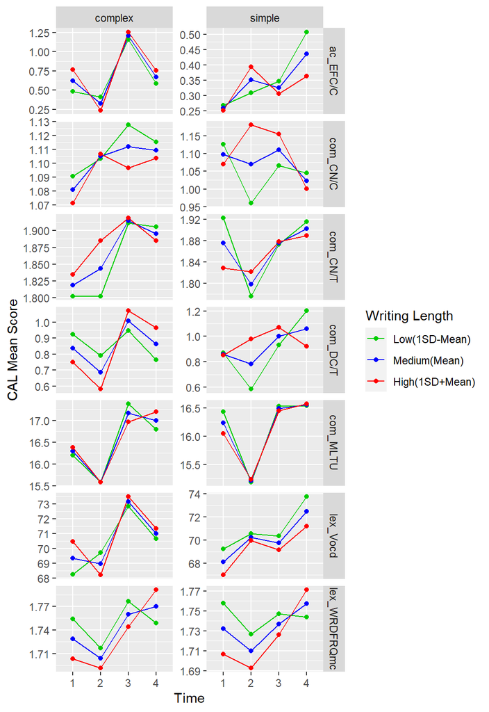

Figure 7. The impact of task repetition on CAL measures moderated by writing length for simple and complex tasks